# Inteligência Artificial como Instrumento de Medição

Minicurso completo em slides · Trilha R

Prof. Dr. Jodavid Ferreira · Departamento de Estatística · UFPE

II DataPOL · 24 a 26 de novembro de 2026 · CCEN/UFPE

“O futuro traz novas perguntas.  
Os dados ampliam nossas formas de responder.”

…mas **quem mede a régua?**

> ou seja, quem estabelece os critérios utilizados para avaliar os resultados? Quem define o que é sucesso? Qual métrica devemos utilizar? O que consideramos uma resposta correta? Quem determina os padrões?

## Uma conferência, 29 mil artigos: volume não é ciência

≈ 29 mil

submissões à trilha principal da AAAI-26, quase o dobro de 2025

AAAI; OpenReview (2026)

6,5–16,9%

do texto de revisões em conferências de IA (2023–24) modificado por LLMs.

## Como ler estes slides

Este é o minicurso **inteiro** em slides: conceitos, **código R** e **saídas**.

- Cada etapa segue o mesmo ritmo: **o que vamos executar → o código → a saída → o que ela significa**
- Todo código com saída foi **executado ao compilar os slides**, a partir dos dados congelados do material
- Chamadas às **APIs** e ao **LLM** não são refeitas ao compilar: o código aparece, e a saída vem dos arquivos gravados quando elas rodaram

```r
# código: fundo cinza, borda azul-escura
x <- 1 + 1
```

```
#> saída: fundo branco, borda azul-clara
```

```
#> saída de uma execução anterior
```

Há uma versão equivalente em **Python** e uma versão só com conceitos.

## Duas perguntas para hoje

### Substantiva

Quando o Congresso legisla sobre **IA**, ele quer **punir**, **regular** ou **promover**?

E isso varia entre campos políticos?

### Metodológica

Se usarmos um **LLM** para responder, **como sabemos se a resposta está certa**?

E como **reproduzir** a resposta daqui a dois anos?

## Por que agora?

- **Eleições de 2026**: primeiras eleições gerais sob a Res. TSE nº 23.755/2026 (rotulagem obrigatória, deepfakes proibidos, IA não pode recomendar voto).  
  Novas regras estabelecem limites para o uso de inteligência artificial na comunicação eleitoral.
- **Marco Legal da IA (PL 2338/2023)**: aprovado no Senado em dez/2024, **aguardando parecer** na Câmara.  
  A proposta busca estabelecer regras para o desenvolvimento e o uso da inteligência artificial no Brasil.
- **304 projetos de lei** sobre IA no Congresso, 120 só em 2026.  
  O volume de propostas mostra o crescente interesse legislativo pela regulamentação da IA.
- LLMs viraram infraestrutura de pesquisa, mas são **instáveis, sensíveis ao prompt e enviesados**.  
  Seus resultados exigem validação, avaliação crítica e atenção à qualidade das respostas.

## A “fase atual” da estatística

- **Breiman (2001)**: duas culturas, *modelar* × *prever*

*Modelar* = explicar como os dados são gerados e medir a incerteza (a estatística clássica).

*Prever* = acertar a resposta, mesmo sem entender o mecanismo (o aprendizado de máquina).

- **2018–2026**: a síntese, com ML **a serviço da inferência**

As previsões do ML viram matéria-prima para estimar efeitos e proporções **com intervalo de confiança válido**

**O fio comum**

Previsões de modelos podem tornar a inferência **mais precisa**, desde que o erro delas seja **medido e corrigido**, e não ignorado.

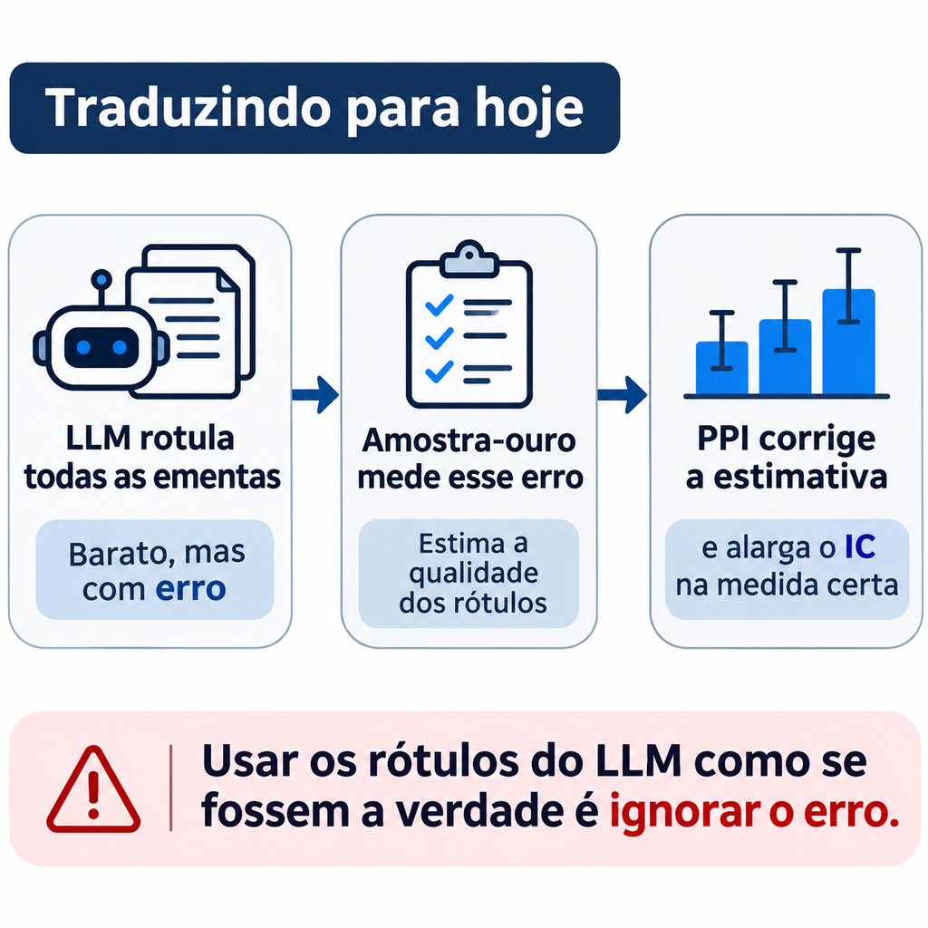

## O que significa medir um instrumento

| Propriedade | Pergunta | Como vamos medir hoje |
| --- | --- | --- |
| **Validade** | Mede o que diz medir? | kappa, F1 e acurácia contra a amostra-ouro, com IC bootstrap |
| **Onde erra** | Que erros comete? | matriz de confusão |
| **Viés diferencial** | Erra igual para todos? | acurácia e viés por campo político |
| **Confiabilidade** | Mede sempre igual? | alfa de Krippendorff entre sementes e entre prompts |
| **Consequência** | O erro muda a conclusão? | ingênuo × PPI × PPI++, simulação de cobertura |
| **Reprodutibilidade** | Outra pessoa chega ao mesmo número? | cache, hashes, `targets`, repetição |

## O caminho de hoje

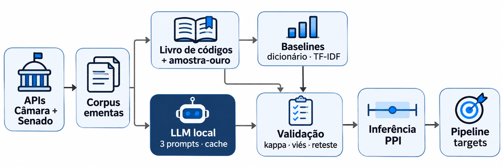

## Organização do material

```
minicurso_IA_medicao/
├── R/            funções + scripts dos blocos 1 a 6
├── python/       a mesma trilha em notebooks (Colab)
├── _targets.R    pipeline reprodutível
├── prompts/      v1, v2, v3 + CHANGELOG
├── modelos/      Modelfile do S5-nano
├── dados/
│   ├── bruto/        respostas das APIs (congeladas)
│   ├── processado/   corpus.csv
│   ├── anotacoes/    referência, amostra-ouro
│   ├── cache_llm/    TODAS as respostas do LLM
│   └── repeticao/    repetição a t = 0
├── resultados/   tabelas e figuras
├── slides/  livro/  docs/
└── CODEBOOK.md  CHECKLIST.md  ROTEIRO.md
```

- Tudo roda **sem internet e sem GPU**, a partir de `dados/`
- O código dos slides é o **mesmo** de `R/`
- Abra o projeto na raiz: os caminhos são relativos a ela

## Preparando o ambiente

**R** (uma vez):

```r
source("R/00_pacotes.R")
```

```
#> pacotes <- c("httr2", "jsonlite", "dplyr", "tidyr", "purrr", "readr", "stringr", "tibble",
#>              "forcats", "ggplot2", "scales", "tm", "SnowballC", "glmnet", "digest",
#>              "targets", "visNetwork", "ellmer")
```

**Para congelar as versões:** `renv::init()` e `renv::snapshot()`

**Python** (alternativa):

```bash
pip install -r requirements.txt
```

ou abra `python/01_coleta.ipynb` no **Google Colab** (a primeira célula baixa o material).

**LLM** (opcional, só para anotar de novo):

```bash
ollama pull hf.co/maritaca-ai/S5-nano-GGUF:Q4_K_M
ollama create s5-nano-instruct \
  -f modelos/Modelfile.s5-nano-instruct
```

## Carregando as funções do minicurso

```r
source("R/funcoes_coleta.R")    # APIs da Câmara e do Senado
source("R/funcoes_medicao.R")   # kappa, alfa, F1, bootstrap, PPI, PPI++
source("R/tema_graficos.R")     # tema e paleta das figuras
source("R/04_anotacao_llm.R")   # chamada ao Ollama, extração do rótulo, cache

CATEGORIAS
```

```
#> [1] "PUNIR"    "REGULAR"  "PROMOVER" "OUTRO"
```

```r
INSTRUMENTO
```

```
#> [1] "s5-nano-instruct"
```

```r
funcoes <- setdiff(as.character(lsf.str()), c("nf", "pc", "trecho"))   # nf/pc/trecho: auxiliares dos slides
funcoes |> sort() |> paste(collapse = "  ") |> strwrap(95) |> cat(sep = "\n")
```

```
#> alfa_krippendorff anota_corpus boot_ic camara_autor camara_partido_na_data camara_proposicoes
#> camara_situacao carrega_corpus carrega_llm carrega_ouro chama_ollama classifica_dicionario
#> compara_estimadores digest_modelo eleitoral_dicionario est_humano est_ingenuo est_ppi
#> est_ppi_plus extrai_partido_senado extrai_rotulo f1_macro ic_normal kappa_cohen limpa_ementa
#> req_json resumo_metricas salva_fig senado_processos tema_minicurso
```

## Os dados que vamos usar

```r
arqs <- list.files("dados", recursive = TRUE, full.names = TRUE)
tibble(pasta = dirname(arqs), kb = file.size(arqs) / 1024) |>
  filter(!grepl("historico_gemma|comparacao_modelos", pasta)) |>
  group_by(pasta) |>
  summarise(arquivos = n(), tamanho_kb = round(sum(kb)))
```

```
#> # A tibble: 6 × 3
#>   pasta                      arquivos tamanho_kb
#>   <chr>                         <int>      <dbl>
#> 1 dados/anotacoes                   4         25
#> 2 dados/bruto                       2        129
#> 3 dados/cache_llm                   6        757
#> 4 dados/processado                  1        116
#> 5 dados/processado/historico        1        114
#> 6 dados/repeticao                   3        380
```

Esses arquivos **são** a pesquisa: quem tiver esta pasta refaz todas as análises, sem APIs nem LLM.

# 1 · Dados legislativos

## O que vamos executar neste bloco

1. Entender **uma requisição** às APIs da Câmara e do Senado
2. Ler as funções de coleta: **retry**, **limite de taxa**, **paginação**, **autor**, **partido na data**
3. As partes que transformam os dados: **partido no Senado**, **limpeza da ementa**, **campo político**
4. Como gerar **corpus** *congelado*
5. Comparar duas coletas feitas com um mês de diferença

## Duas APIs abertas, sem chave

### Câmara dos Deputados

`dadosabertos.camara.leg.br/api/v2`

- `/proposicoes`: busca por palavra-chave, ano, tipo
- `/proposicoes/{id}/autores`
- `/proposicoes/{id}` (situação)
- `/deputados/{id}/historico`

### Senado Federal

`legis.senado.leg.br/dadosabertos`

- `/processo`: busca por termo, sigla e datas
- a **autoria já vem com partido e UF** na data: “Senador Fulano (PSD/MG)”

**Termos:** *inteligência artificial*, *deepfake*, *deep fake*, *conteúdo sintético* · **Tipo:** PL · **Anos:** 2019–2026

## Anatomia de uma requisição

```
https://dadosabertos.camara.leg.br/api/v2/proposicoes?keywords=deepfake&ano=2024&siglaTipo=PL&itens=100&pagina=1
└──────────────── URL base ──────────────┘└ endpoint ┘└──────────────── parâmetros (query) ─────────────────┘
```

| Parâmetro | Papel | Decisão de medição |
| --- | --- | --- |
| `keywords` | termo de busca | o **indexador** da Câmara decide o que “contém” o termo |
| `ano` | ano de apresentação | o filtro por **data** aceita no máximo 3 meses |
| `siglaTipo` | PL, PEC, PLP… | só **projetos de lei** |
| `itens`, `pagina` | paginação | no máximo 100 por página |

## Uma chamada, em R

```r
library(httr2)
resp <- request("https://dadosabertos.camara.leg.br/api/v2/proposicoes") |>
  req_url_query(keywords = "inteligência artificial", ano = 2026,
                siglaTipo = "PL", itens = 100) |>
  req_headers(Accept = "application/json") |>
  req_perform() |>
  resp_body_json()

length(resp$dados)          # quantas proposições vieram nesta página
resp$dados[[1]]$ementa      # a ementa da primeira
```

- `request()` monta a URL; `req_url_query()` acrescenta os parâmetros
- `req_perform()` faz a chamada; `resp_body_json()` transforma o JSON numa **lista** do R
- Cada elemento de `resp$dados` é uma proposição: `id`, `siglaTipo`, `numero`, `ano`, `ementa`, `dataApresentacao`

## O que ficou guardado da resposta

A coleta gravou as respostas, já em formato de tabela, em `dados/bruto/`:

```r
camara_raw <- read_csv("dados/bruto/camara_raw.csv")
dim(camara_raw)
```

```
#> [1] 265  14
```

```r
camara_raw |>
  select(id, sigla, numero, ano, data_apresentacao, autor, partido, uf) |>
  head(6)
```

```
#> # A tibble: 6 × 8
#>        id sigla numero   ano data_apresentacao   autor            partido uf
#>     <dbl> <chr>  <dbl> <dbl> <dttm>              <chr>            <chr>   <chr>
#> 1 2236340 PL        21  2020 2020-02-04 11:57:00 Eduardo Bismarck PDT     CE
#> 2 2236943 PL       240  2020 2020-02-11 17:23:00 Léo Moraes       PODE    RO
#> 3 2284814 PL      1969  2021 2021-05-26 16:54:00 Gustavo Fruet    PDT     PR
#> 4 2318674 PL       705  2022 2022-03-24 16:16:00 Helio Lopes      UNIÃO   RJ
#> 5 2343349 PL      3009  2022 2022-12-15 13:13:00 Alexis Fonteyne  NOVO    SP
#> 6 2349685 PL       759  2023 2023-03-01 15:20:00 Lebrão           UNIÃO   RO
```

`id` é o identificador interno da Câmara; é com ele que pedimos autores e situação.

## Boas práticas com APIs públicas: `req_json()`

```r
req_json <- function(url, query = list()) {
  request(url) |>
    req_url_query(!!!query) |>
    req_headers(Accept = "application/json") |>
    req_user_agent("Minicurso DataPOL/UFPE (fins acadêmicos)") |>
    req_retry(max_tries = 6, backoff = ~ 2^.x,       # tenta de novo também em erros 5xx
              is_transient = \(resp) resp_status(resp) %in% c(429, 500, 502, 503, 504)) |>
    req_throttle(rate = 5) |>                # no máximo 5 requisições/segundo
    req_perform() |>
    resp_body_json(simplifyVector = FALSE)
}
```

- **`req_user_agent()`**: identifica quem está chamando · **`req_throttle(rate = 5)`**: no máximo 5 requisições por segundo
- **`req_retry()`**: tenta de novo, com espera crescente (2, 4, 8 s…)
- **`is_transient`**: também nos erros **5xx**. Na recoleta de 06/11, a Câmara respondeu **504** no meio da coleta, e o padrão do `httr2` não repete esse erro

## Paginação: buscar até acabar

```r
camara_proposicoes <- function(termo, ano, tipos = "PL") {
  pagina <- 1
  saida <- list()
  repeat {
    res <- req_json(
      file.path(URL_CAMARA, "proposicoes"),
      list(keywords = termo, ano = ano, siglaTipo = paste(tipos, collapse = ","),
           itens = 100, pagina = pagina, ordem = "ASC", ordenarPor = "id")
    )
    saida <- c(saida, res$dados)
    if (length(res$dados) < 100) break
    pagina <- pagina + 1
  }
  map_dfr(saida, \(x) tibble(
    id = x$id, sigla = x$siglaTipo, numero = x$numero, ano = x$ano,
    ementa = x$ementa, data_apresentacao = x$dataApresentacao
  ))
}
```

`repeat` pede a página 1, 2, 3… até vir uma página com **menos de 100** itens. No fim, `map_dfr()` transforma a lista de proposições numa tabela, uma linha por proposição.

## Quem é o autor?

```r
camara_autor <- function(id) {
  res <- req_json(file.path(URL_CAMARA, "proposicoes", id, "autores"))$dados
  if (length(res) == 0) return(tibble(id = id))
  a <- res[[which.min(map_int(res, \(x) x$ordemAssinatura %||% 99L))]]
  tibble(id = id, autor = a$nome, tipo_autor = a$tipo,
         uri_autor = a$uri %||% NA_character_, n_autores = length(res))
}
```

- Um PL pode ter **vários autores**: escolhemos o primeiro signatário (`ordemAssinatura`)
- `%||%` devolve o lado direito quando o campo vem vazio (`NULL`)
- Guardamos a **URI** do autor: é por ela que buscamos o partido
- `n_autores` fica registrado: projetos coletivos podem ser analisados à parte

## O partido de quem? E quando?

Queremos o partido do autor **na data de apresentação**, não o partido de hoje.

- A API da Câmara tem o **histórico** de cada deputado: `/deputados/{id}/historico`
- Armadilha: o histórico traz registros “partido no início da legislatura” **datados de 2023-02-01 para legislaturas antigas**, com `situacao` vazia
- Sem filtrar esses registros, um deputado do **PL em 2023** aparecia como **PMDB** ou **PFL** num projeto de 2023
- A solução é uma linha de código, mas só aparece para quem **olha os dados**

## `camara_partido_na_data()`

```r
camara_partido_na_data <- function(uri_deputado, data_ref) {
  vazio <- tibble(partido = NA_character_, uf = NA_character_)
  if (is.na(uri_deputado) || !str_detect(uri_deputado, "/deputados/")) return(vazio)
  h <- req_json(paste0(uri_deputado, "/historico"))$dados
  h <- map_dfr(h, \(x) tibble(dia = substr(x$dataHora %||% NA, 1, 10),
                              partido = x$siglaPartido %||% NA_character_,
                              uf = x$siglaUf %||% NA_character_,
                              situacao = x$situacao %||% NA_character_))
  # Atenção: a API inclui registros "Nome/Partido no início da legislatura" com a
  # data de 2023-02-01 para TODAS as legislaturas anteriores (situacao = NULL).
  # Sem este filtro, um deputado do PL em 2023 aparece como PMDB ou PFL.
  h <- h |> filter(!is.na(partido), !is.na(dia), !is.na(situacao)) |> arrange(dia)
  if (nrow(h) == 0) return(vazio)
  antes <- h |> filter(dia <= substr(data_ref, 1, 10))
  linha <- if (nrow(antes) > 0) slice_tail(antes, n = 1) else slice_head(h, n = 1)
  select(linha, partido, uf)
}
```

## Testando a regra

Um histórico **fictício**, com o registro problemático da API:

```r
h <- tribble(
  ~dia,         ~partido, ~uf,  ~situacao,
  "2007-02-01", "PFL",    "SP", NA,          # "início da legislatura" com data errada
  "2023-02-01", "PMDB",   "SP", NA,          # idem: é isto que a API devolve
  "2019-02-01", "PSL",    "SP", "Exercício",
  "2022-03-30", "PL",     "SP", "Exercício"
)
data_ref <- "2023-05-10"

ingenuo <- h |> filter(dia <= data_ref) |> arrange(dia) |> slice_tail(n = 1)
correto <- h |> filter(!is.na(situacao), dia <= data_ref) |> arrange(dia) |> slice_tail(n = 1)
bind_rows(ingenuo = ingenuo, correto = correto, .id = "regra")
```

```
#> # A tibble: 2 × 5
#>   regra   dia        partido uf    situacao
#>   <chr>   <chr>      <chr>   <chr> <chr>
#> 1 ingenuo 2023-02-01 PMDB    SP    <NA>
#> 2 correto 2022-03-30 PL      SP    Exercício
```

## Senado: o partido vem no texto

No Senado, a autoria já vem com partido e UF **na data**. Basta extrair com uma expressão regular:

```r
extrai_partido_senado <- function(autoria) {
  m <- str_match(autoria, "\\(([A-Za-zÀ-ú ]+)/([A-Z]{2})\\)")
  tibble(partido = m[, 2], uf = m[, 3])
}
```

```r
autorias <- c("Senador Styvenson Valentim (PODEMOS/RN)",
              "Senadora Daniella Ribeiro (PSD/PB)",
              "Comissão de Comunicação e Direito Digital")
extrai_partido_senado(autorias)
```

```
#> # A tibble: 3 × 2
#>   partido uf
#>   <chr>   <chr>
#> 1 PODEMOS RN
#> 2 PSD     PB
#> 3 <NA>    <NA>
```

Autoria de **comissão** não tem partido: vira `NA` e, mais adiante, “Sem partido/Outro”.

## Limpeza mínima e transparente da ementa

```r
limpa_ementa <- function(x) {
  x |>
    str_replace_all("[\r\n]+", " ") |>
    str_replace("(?i)\\s*NOVA EMENTA:.*$", "") |>   # mantém a ementa original
    str_squish()
}
```

Um caso real da Câmara, em que a ementa foi **reescrita** durante a tramitação:

```r
bruta <- camara_raw$ementa[camara_raw$id == 2236340]
strwrap(bruta, 100)
```

```
#> [1] "Estabelece princípios, direitos e deveres para o uso de inteligência artificial no Brasil, e dá"
#> [2] "outras providências.  NOVA EMENTA: Estabelece fundamentos, princípios e diretrizes para o"
#> [3] "desenvolvimento e a aplicação da inteligência artificial no Brasil; e dá outras providências."
```

```r
strwrap(limpa_ementa(bruta), 100)
```

```
#> [1] "Estabelece princípios, direitos e deveres para o uso de inteligência artificial no Brasil, e dá"
#> [2] "outras providências."
```

*Decisão de medição:* ficamos com a ementa **original**, a que o autor apresentou.

## Montando o corpus (trecho de `R/01_coleta.R`)

```r
corpus <- bind_rows(senado_pad, camara_pad) |>
  distinct(identificacao, .keep_all = TRUE) |>        # PL do Senado remetido à Câmara: fica o da origem
  mutate(ementa  = limpa_ementa(ementa),
         partido = str_trim(str_to_upper(partido))) |>
  filter(ano %in% ANOS, nchar(ementa) > 20) |>
  arrange(data_apresentacao) |>                         # ordem estável: doc_id não muda numa recoleta
  mutate(doc_id = sprintf("doc%04d", row_number()), .before = 1)

write_csv(corpus, "dados/processado/corpus.csv")
```

- `distinct(identificacao)` remove a **duplicata** entre casas
- `arrange(data_apresentacao)` + `doc_id`: o identificador de cada projeto fica **estável** entre coletas
- O corpus é salvo **com a data da coleta** (`data_coleta`)

## Campo político: uma medida dentro da medida

```r
ESQUERDA <- c("PSOL", "PT", "PCDOB", "PDT", "PSB", "REDE", "PV")
CENTRO   <- c("MDB", "PSDB", "CIDADANIA", "PSD", "SOLIDARIEDADE", "AVANTE", "PMB")
DIREITA  <- c("PL", "PP", "UNIÃO", "REPUBLICANOS", "NOVO", "PSC", "PTB", "PODE", "PODEMOS",
              "PATRIOTA", "PRD", "DEM", "PSL", "PROS", "PRTB", "AGIR", "DC", "PMN", "MOBILIZA")
corpus <- read_csv("dados/processado/corpus.csv")
corpus |>
  mutate(campo2 = case_when(partido %in% ESQUERDA ~ "Esquerda", partido %in% CENTRO ~ "Centro",
                            partido %in% DIREITA ~ "Direita", TRUE ~ "Sem partido/Outro")) |>
  count(campo2, campo)
```

```
#> # A tibble: 4 × 3
#>   campo2            campo                 n
#>   <chr>             <chr>             <int>
#> 1 Centro            Centro               61
#> 2 Direita           Direita             155
#> 3 Esquerda          Esquerda             80
#> 4 Sem partido/Outro Sem partido/Outro     8
```

## O corpus

```r
glimpse(corpus)
```

```
#> Rows: 304
#> Columns: 14
#> $ doc_id            <chr> "doc0001", "doc0002", "doc0003", "doc0004", "doc0005", "doc0006", "doc00…
#> $ casa              <chr> "Senado", "Senado", "Câmara", "Senado", "Câmara", "Senado", "Câmara", "S…
#> $ identificacao     <chr> "PL 5051/2019", "PL 5691/2019", "PL 240/2020", "PL 872/2021", "PL 1969/2…
#> $ ano               <dbl> 2019, 2019, 2020, 2021, 2021, 2021, 2022, 2022, 2022, 2022, 2023, 2023, …
#> $ data_apresentacao <date> 2019-09-16, 2019-10-24, 2020-02-11, 2021-03-12, 2021-05-26, 2021-09-30,…
#> $ ementa            <chr> "Estabelece os princípios para o uso da Inteligência Artificial no Brasi…
#> $ autor             <chr> "Senador Styvenson Valentim", "Senador Styvenson Valentim", "Léo Moraes"…
#> $ tipo_autor        <chr> "Senador(a)", "Senador(a)", "Deputado(a)", "Senador(a)", "Deputado(a)", …
#> $ partido           <chr> "PODEMOS", "PODEMOS", "PODE", "MDB", "PDT", NA, "UNIÃO", "PODEMOS", NA, …
#> $ uf                <chr> "RN", "RN", "RO", "PB", "PR", NA, "RJ", "GO", NA, "SP", "RO", "MT", "SP"…
#> $ situacao          <chr> NA, "PREJUDICADA", "Arquivada", "PREJUDICADA", "Arquivada", "PREJUDICADA…
#> $ campo             <chr> "Direita", "Direita", "Direita", "Centro", "Esquerda", "Sem partido/Outr…
#> $ ano_eleitoral     <lgl> FALSE, FALSE, TRUE, FALSE, FALSE, FALSE, TRUE, TRUE, TRUE, TRUE, FALSE, …
#> $ data_coleta       <date> 2026-11-06, 2026-11-06, 2026-11-06, 2026-11-06, 2026-11-06, 2026-11-06,…
```

## Quantos projetos, de onde e quando?

```r
corpus |>
  count(casa, ano) |>
  tidyr::pivot_wider(names_from = ano, values_from = n, values_fill = 0)
```

```
#> # A tibble: 2 × 9
#>   casa   `2020` `2021` `2022` `2023` `2024` `2025` `2026` `2019`
#>   <chr>   <int>  <int>  <int>  <int>  <int>  <int>  <int>  <int>
#> 1 Câmara      1      1      2     34     43     73    106      0
#> 2 Senado      0      2      2      6     12      6     14      2
```

```r
corpus |>
  count(campo, casa) |>
  tidyr::pivot_wider(names_from = casa, values_from = n, values_fill = 0) |>
  mutate(Total = Câmara + Senado)
```

```
#> # A tibble: 4 × 4
#>   campo             Câmara Senado Total
#>   <chr>              <int>  <int> <int>
#> 1 Centro                47     14    61
#> 2 Direita              138     17   155
#> 3 Esquerda              74      6    80
#> 4 Sem partido/Outro      1      7     8
```

## Quem mais apresenta?

```r
corpus |>
  filter(!is.na(partido)) |>
  count(partido, campo, sort = TRUE) |>
  mutate(prop = round(n / sum(n), 3)) |>
  head(10)
```

```
#> # A tibble: 10 × 4
#>    partido      campo        n  prop
#>    <chr>        <chr>    <int> <dbl>
#>  1 PT           Esquerda    42 0.142
#>  2 PL           Direita     40 0.135
#>  3 PODE         Direita     31 0.105
#>  4 REPUBLICANOS Direita     30 0.101
#>  5 MDB          Centro      26 0.088
#>  6 UNIÃO        Direita     24 0.081
#>  7 PP           Direita     16 0.054
#>  8 PDT          Esquerda    13 0.044
#>  9 PSD          Centro      12 0.041
#> 10 CIDADANIA    Centro      11 0.037
```

8 projetos não têm partido (comissões, Executivo, Senado Federal como autor).

## A explosão legislativa: o código

```r
ref <- read_csv("dados/anotacoes/referencia_completa.csv")

corpus |>
  left_join(select(ref, doc_id, categoria), by = "doc_id") |>
  count(ano, categoria = factor(categoria, levels = CATEGORIAS)) |>
  ggplot(aes(factor(ano), n, fill = categoria == "PUNIR")) +
  geom_col(width = .7) +
  facet_wrap(~categoria, nrow = 1) +
  scale_fill_manual(values = c(`TRUE` = AZUIS[3], `FALSE` = CINZA_CLARO), guide = "none") +
  labs(title = "Projetos de lei sobre IA no Congresso, por ano e categoria (referência)",
       x = NULL, y = "Projetos") +
  tema_minicurso() +
  theme(axis.text.x = element_text(angle = 90, vjust = .5))
```

## A explosão legislativa: o código

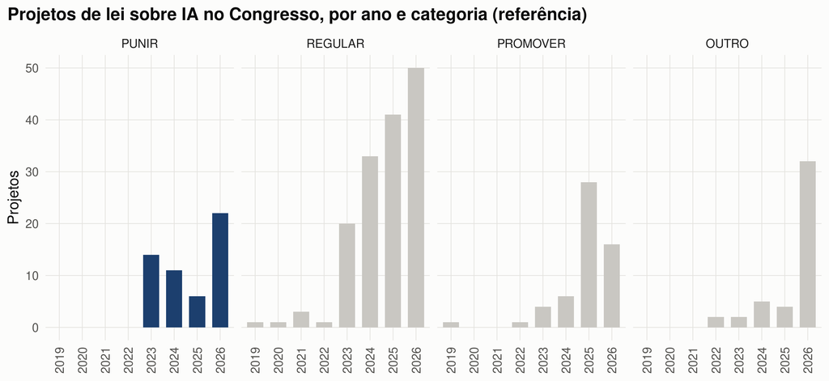

## Duplicatas: o mesmo PL nas duas casas

```r
senado_raw <- read_csv("dados/bruto/senado_raw.csv")
senado_raw |> filter(identificacao == "PL 2338/2023") |> select(identificacao, data_apresentacao, autoria, situacao)
```

```
#> # A tibble: 1 × 4
#>   identificacao data_apresentacao autoria                          situacao
#>   <chr>         <date>            <chr>                            <chr>
#> 1 PL 2338/2023  2023-05-03        Senador Rodrigo Pacheco (PSD/MG) REMETIDA À CÂMARA DOS DEPUTADOS
```

```r
camara_raw |> filter(numero == 2338, ano == 2023) |> select(sigla, numero, ano, data_apresentacao, autor)
```

```
#> # A tibble: 1 × 5
#>   sigla numero   ano data_apresentacao   autor
#>   <chr>  <dbl> <dbl> <dttm>              <chr>
#> 1 PL      2338  2023 2025-03-17 17:21:00 Senado Federal - Rodrigo Pacheco
```

```r
corpus |> filter(identificacao == "PL 2338/2023") |> select(doc_id, casa, identificacao, partido, campo)
```

```
#> # A tibble: 1 × 5
#>   doc_id  casa   identificacao partido campo
#>   <chr>   <chr>  <chr>         <chr>   <chr>
#> 1 doc0018 Senado PL 2338/2023  PSD     Centro
```

O Marco Legal da IA aparece nas duas casas. Mantemos o registro do **Senado** (casa de origem), que traz o partido do autor na data.

## A mesma coleta, um mês depois

```r
antigo <- read_csv("dados/processado/historico/corpus_2026-10-08.csv")
novos  <- anti_join(corpus, antigo, by = "identificacao")
sairam <- anti_join(antigo, corpus, by = "identificacao")
comum  <- inner_join(antigo, corpus, by = "identificacao", suffix = c("_out", "_nov"))

tibble(coleta_08_10 = nrow(antigo), coleta_06_11 = nrow(corpus), novos = nrow(novos),
       sairam = nrow(sairam),
       ementa_mudou   = sum(comum$ementa_out != comum$ementa_nov),
       situacao_mudou = sum(coalesce(comum$situacao_out, "") != coalesce(comum$situacao_nov, "")))
```

```
#> # A tibble: 1 × 6
#>   coleta_08_10 coleta_06_11 novos sairam ementa_mudou situacao_mudou
#>          <int>        <int> <int>  <int>        <int>          <int>
#> 1          298          304     6      0            0             46
```

```r
novos |> select(doc_id, casa, identificacao, data_apresentacao)
```

```
#> # A tibble: 6 × 4
#>   doc_id  casa   identificacao data_apresentacao
#>   <chr>   <chr>  <chr>         <date>
#> 1 doc0299 Câmara PL 5580/2026  2026-10-15
#> 2 doc0300 Câmara PL 5606/2026  2026-10-19
#> 3 doc0301 Câmara PL 5715/2026  2026-10-30
#> 4 doc0302 Câmara PL 5716/2026  2026-10-30
#> 5 doc0303 Senado PL 5726/2026  2026-11-03
#> 6 doc0304 Câmara PL 5729/2026  2026-11-03
```

## A coleta também é medição

- **Limite de 3 meses** no filtro de data → filtrar por `ano`
- **Partido “na data”**: registros de 2023 para legislaturas antigas → filtrar `situacao`
- **Busca por palavra-chave** depende de um indexador: falsos positivos (Lei Geral das Atividades Nucleares?) e possíveis omissões → categoria **OUTRO**
- **Duplicatas** entre casas → `distinct(identificacao)`
- **Erros 5xx** no meio da coleta → `req_retry()` com `is_transient`
- **APIs mudam**: em um mês, 6 projetos novos e 46 situações de tramitação diferentes → **congelar com data**

## Resumo do bloco 1

**Executamos**

- leitura dos dados brutos e do corpus
- regras de partido (Câmara e Senado)
- limpeza da ementa e campo político
- descrição do corpus e comparação entre coletas

**Levamos para os próximos blocos**

- `corpus`: 304 ementas, uma por projeto
- `doc_id` estável
- `campo` do autor (para o viés diferencial)
- a lição: **cada passo da coleta é uma decisão de medição**

# 2 · Codificar é medir

## O que vamos executar neste bloco

1. **Livro de Códigos**: categorias, regras de decisão, variável eleitoral
2. **Ementas difíceis** e discutir como codificá-las
3. **Codificação de referência**: quem a fez, como, e seu status
4. Contar **quantos de cada classe** e ver **o que foi parar em OUTRO**
5. **Selecionar a amostra-ouro** com semente fixa e conferir que o sorteio é reproduzível

**Por que este bloco vem antes do LLM**

Um LLM só pode ser avaliado contra uma **referência**. E uma referência só existe se o conceito tiver uma **definição operacional** escrita.

## Livro de códigos

| Código | Instrumento central | Exemplo |
| --- | --- | --- |
| **PUNIR** | *penal:* crime, pena, Código Penal, parte penal do ECA | “tipifica o crime de deepfake sexual” |
| **REGULAR** | *regras não penais:* deveres, rotulagem, direitos, responsabilidade civil | “obriga identificar conteúdo gerado por IA” |
| **PROMOVER** | fomento, ensino, adoção de IA pelo Estado | “inclui IA no currículo do ensino médio” |
| **OUTRO** | não trata de IA, algoritmos ou conteúdo sintético | falsos positivos da busca |

**Unidade de análise:** a **ementa**, sozinha. Sem inteiro teor, sem olhar o autor.

## Regras de decisão

1. **Precedência:** PUNIR > REGULAR > PROMOVER
2. “Responsabilização” ou “penalidades” **sem** crime, pena ou Código Penal → **REGULAR**
3. Marcos gerais (“princípios, direitos e deveres”) → **REGULAR**
4. Proteção de trabalhadores diante da automação → **REGULAR**
5. Obrigar o Estado ou empresas a **usar** IA → **PROMOVER**
6. Deepfake, montagem, nudez falsa = conteúdo sintético, mesmo sem “inteligência artificial”
7. Na dúvida com OUTRO: *a ementa, sozinha, deixa claro que o objeto é IA?*

**Segunda variável:** `eleitoral` (0/1), independente da categoria: eleições, campanhas, candidatos, Código Eleitoral, violência política.

## A codificação de referência

```r
ref <- read_csv("dados/anotacoes/referencia_completa.csv")
head(ref, 4)
```

```
#> # A tibble: 4 × 6
#>   doc_id  categoria eleitoral codificador revisado obs
#>   <chr>   <chr>         <dbl> <chr>       <lgl>    <chr>
#> 1 doc0001 REGULAR           0 preliminar  FALSE    <NA>
#> 2 doc0002 PROMOVER          0 preliminar  FALSE    <NA>
#> 3 doc0003 REGULAR           0 preliminar  FALSE    <NA>
#> 4 doc0004 REGULAR           0 preliminar  FALSE    <NA>
```

```r
ref |> count(codificador, revisado)
```

```
#> # A tibble: 1 × 3
#>   codificador revisado     n
#>   <chr>       <lgl>    <int>
#> 1 preliminar  FALSE      304
```

## De onde vêm os rótulos de referência?

- As 304 ementas têm um rótulo de **referência**: é a “régua” do minicurso
- **Quem codificou:** outra IA, o **Claude Opus 5.5** (Anthropic), coautor deste material. **Não** é o S5-nano, o instrumento que vamos avaliar
- **Como:** aplicando o **livro de códigos** ementa por ementa, lendo **só a ementa** (sem autor, sem inteiro teor);
- **Quando:** 298 ementas da coleta de 08/10/2026 e as 6 novas da coleta de 06/11/2026

**O que isso muda**

Sem revisão humana, o kappa do bloco 5 mede a concordância **entre duas IAs** (S5-nano × Claude), não a validade contra humanos. Se as duas erram nos mesmos casos, a concordância **infla**.

Os números **ensinam o método**; não são achados sobre o Congresso.

**Pergunta para a turma**

Por que não aceitar o rótulo do Claude como “verdade” e dispensar os humanos?

## Quantos de cada classe?

```r
corpus |>
  inner_join(ref, by = "doc_id") |>
  count(categoria = factor(categoria, levels = CATEGORIAS), casa) |>
  tidyr::pivot_wider(names_from = casa, values_from = n) |>
  mutate(Total = Câmara + Senado, `%` = round(100 * Total / sum(Total), 1))
```

```
#> # A tibble: 4 × 5
#>   categoria Câmara Senado Total   `%`
#>   <fct>      <int>  <int> <int> <dbl>
#> 1 PUNIR         40     13    53  17.4
#> 2 REGULAR      136     14   150  49.3
#> 3 PROMOVER      47      9    56  18.4
#> 4 OUTRO         37      8    45  14.8
```

- **Total:** 304 ementas · **REGULAR é metade** do corpus: chutar sempre REGULAR é o **piso** de qualquer instrumento

## O que foi parar em OUTRO?

45 ementas (14,8% do corpus, 32 delas de 2026) vieram na busca, mas a **ementa, sozinha, não trata de IA nem de conteúdo sintético** (regra 7).

| Tipo | Exemplos reais do corpus (ementas resumidas) |
| --- | --- |
| **Temas digitais vizinhos**, sem IA na ementa | violência contra a mulher em ambiente digital · crimes cibernéticos · LGPD para crianças · inclusão e soberania digital · nuvem soberana |
| **Leis penais** que não citam IA nem conteúdo sintético | aumento de pena dos arts. 216-B e 218-C do Código Penal · estelionato · usura · ameaça pelo Pix |
| **Falsos positivos puros** | Lei Geral das Atividades Nucleares · transplante de órgãos · Código de Trânsito · processo administrativo |

**Por que vieram?** A busca das APIs não olha só a ementa (o indexador usa também outros campos, como a indexação do projeto), e o texto completo pode até tratar de IA. Mas a unidade de análise é a **ementa**.

**Pergunta para a turma**

A proporção PUNIR deve ser calculada sobre as 304 ementas ou só sobre as que tratam de IA?

Sobre 304: 17,4% · sobre 259: 20,5%. O denominador é uma **decisão de medição** (aqui, as 304).

## A amostra-ouro: um sorteio

```r
N_OURO <- 120      # ~40% do corpus: custo humano × precisão
set.seed(2026)
ouro_ids <- sample(corpus$doc_id, N_OURO)
head(ouro_ids, 12)
```

```
#>  [1] "doc0221" "doc0121" "doc0294" "doc0045" "doc0111" "doc0108" "doc0164" "doc0176" "doc0287"
#> [10] "doc0079" "doc0110" "doc0290"
```

```r
# o sorteio é reproduzível: confere com o arquivo do material
identical(sort(ouro_ids), sort(ouro$doc_id))
```

```
#> [1] TRUE
```

- **Aleatória:** nem a “mais fácil”, nem a “mais interessante”. É o que permite que o erro medido nela valha para o corpus todo
- **Semente fixa:** qualquer pessoa sorteia **as mesmas** 120 ementas

## A amostra-ouro representa o corpus?

```r
bind_rows(
  corpus      = ref,
  amostra_ouro = filter(ref, doc_id %in% ouro_ids),
  .id = "conjunto") |>
  count(conjunto, categoria) |>
  group_by(conjunto) |> mutate(prop = round(n / sum(n), 2)) |> ungroup() |>
  tidyr::pivot_wider(names_from = conjunto, values_from = c(n, prop))
```

```
#> # A tibble: 4 × 5
#>   categoria n_amostra_ouro n_corpus prop_amostra_ouro prop_corpus
#>   <chr>              <int>    <int>             <dbl>       <dbl>
#> 1 OUTRO                 13       45              0.11        0.15
#> 2 PROMOVER              16       56              0.13        0.18
#> 3 PUNIR                 22       53              0.18        0.17
#> 4 REGULAR               69      150              0.58        0.49
```

Proporções parecidas, como se espera de um sorteio. Diferenças existem, e é por isso que a inferência leva a amostra em conta.

## Quanto **nós** concordamos?

**Levantem a mão:** PUNIR, REGULAR, PROMOVER ou OUTRO?

1. *“Estabelece condições, deveres e restrições ao uso de óculos inteligentes com recursos de inteligência artificial, altera o Código de Trânsito Brasileiro e o Código Penal…”* (doc0185)
2. *“Dispõe sobre medidas de prevenção, combate e responsabilização relacionadas à criação e disseminação de manipulação digital de conteúdo sexual (deepfakes)…”* (doc0233)

**Referência:**

1 → **PUNIR** (altera o Código Penal; PUNIR precede REGULAR)

2 → **REGULAR** (“responsabilização” sem crime nem pena;regra 2).

## Por que isso importa

**O teto do instrumento**

Se humanos treinados não concordam entre si, o LLM **não tem um alvo**. A concordância humano × humano é o **teto realista** de qualquer instrumento automático.

- Kappa de 0,65 entre LLM e referência é **ruim** se humanos concordam a 0,90…
  - …e é **excelente** se eles concordam a 0,60
- Por isso o livro de códigos é testado **com humanos** antes de ir para o LLM
- Neste material ainda não há dois codificadores humanos:
  - o teto humano é **desconhecido**

## Resumo do bloco 2

**Executamos**

- leitura da referência: quem a fez e seu status
- contagem das classes e o que foi para OUTRO
- sorteio reproduzível da amostra-ouro
- comparação ouro × corpus

**Levamos para os próximos blocos**

- `ouro`:
  - 120 ementas com rótulo de referência (preliminar, de outra IA)
- o livro de códigos, que vira **prompt** no bloco 4
- a pergunta:
  - **qual é o teto de concordância?**

# 3 · Baselines: quanto se acerta **sem** LLM?

## O que vamos executar neste bloco

1. Um **dicionário**: expressões regulares que traduzem o livro de códigos em regras
2. As **métricas** de acerto, implementadas “na mão”: acurácia, F1, **kappa**
3. Um modelo clássico: **TF-IDF + regressão logística**, com **validação cruzada**
4. A comparação com o **piso**: alocar sempre para a classe mais frequente

**Por que baselines**

Um LLM só “vale a pena” se superar instrumentos mais baratos e mais transparentes **de forma estatisticamente consistente**. Isso é uma afirmação a testar, não uma impressão.

## O dicionário: regras explícitas

```r
names(REGEX)
```

```
#> [1] "punir"     "ia"        "promover"  "eleitoral"
```

```r
REGEX$punir
```

```
#> [1] "c[oó]digo penal|\\bpenas?\\b|\\bcrimes?\\b|criminaliz|tipific|hediond"
```

```r
strwrap(REGEX$ia, 100)
```

```
#> [1] "intelig[eê]ncia artificial|\\bia\\b|algor[ií]tm|automatiz|automa[cç][aã]o|sint[eé]tic|deep"
#> [2] "?fake|deepvoice|manipula|chatbot|reconhecimento facial|aut[oô]nom|\\binteligente|réplicas?"
#> [3] "digit|simul"
```

```r
strwrap(REGEX$promover, 100)
```

```
#> [1] "incentiv|fomento|\\bfundo\\b|curr[ií]cul|ensino|educa[cç]|capacita|forma[cç][aã]o|pesquisa|desenvolvimento"
#> [2] "da|programa nacional|institui o sistema|obrigatoriedade d[eo] uso|utiliza[cç][aã]o de"
#> [3] "(ferramentas|tecnologias|sistemas)"
```

## Função para classificar para as regras

```r
classifica_dicionario <- function(ementa) {
  x <- str_to_lower(ementa)
  case_when(
    str_detect(x, REGEX$punir) & str_detect(x, REGEX$ia) ~ "PUNIR",
    !str_detect(x, REGEX$ia)                               ~ "OUTRO",
    str_detect(x, REGEX$promover)                          ~ "PROMOVER",
    TRUE                                                   ~ "REGULAR"
  ) |> factor(levels = CATEGORIAS)
}
```

- `case_when()` avalia as regras **em ordem**: a primeira verdadeira vence
- A ordem implementa a **precedência** do livro de códigos (PUNIR > … )
- Sem termo de IA → **OUTRO** (falso positivo da busca)
- Barato, transparente, **100% auditável**

## Testando o dicionário

```r
exemplos <- c(
  "Altera o Código Penal para tipificar a criação de deepfake de nudez.",
  "Dispõe sobre a rotulagem de conteúdo gerado por inteligência artificial.",
  "Institui programa de formação em inteligência artificial nas escolas.",
  "Altera a Lei nº 9.503 para dispor sobre a carteira de habilitação.",
  "Prevê penalidades administrativas para plataformas que não removam deepfakes.",
  "Cria o crime de fraude eletrônica com uso de algoritmos.")
tibble(ementa = exemplos, dicionario = classifica_dicionario(exemplos),
       eleitoral = eleitoral_dicionario(exemplos))
```

```
#> # A tibble: 6 × 3
#>   ementa                                                                        dicionario eleitoral
#>   <chr>                                                                         <fct>      <lgl>
#> 1 Altera o Código Penal para tipificar a criação de deepfake de nudez.          PUNIR      FALSE
#> 2 Dispõe sobre a rotulagem de conteúdo gerado por inteligência artificial.      REGULAR    FALSE
#> 3 Institui programa de formação em inteligência artificial nas escolas.         PROMOVER   FALSE
#> 4 Altera a Lei nº 9.503 para dispor sobre a carteira de habilitação.            OUTRO      FALSE
#> 5 Prevê penalidades administrativas para plataformas que não removam deepfakes. REGULAR    FALSE
#> 6 Cria o crime de fraude eletrônica com uso de algoritmos.                      PUNIR      FALSE
```

A 5ª ementa: “penalidades” sem crime, REGULAR pelo livro de códigos. O dicionário acertou porque `\bpenas?\b` não casa com “penalidades”.

## Aplicando à amostra-ouro

```r
ouro <- carrega_ouro() |>
  left_join(select(corpus, doc_id, ementa), by = "doc_id") |>
  mutate(pred_dic = classifica_dicionario(ementa))

ouro |> transmute(doc_id, humano = categoria, dicionario = pred_dic,
                  ementa = str_trunc(ementa, 70)) |> head(8)
```

```
#> # A tibble: 8 × 4
#>   doc_id  humano   dicionario ementa
#>   <chr>   <chr>    <fct>      <chr>
#> 1 doc0001 REGULAR  REGULAR    Estabelece os princípios para o uso da Inteligência Artificial no B...
#> 2 doc0003 REGULAR  REGULAR    Cria a Lei da Inteligência Artificial, e dá outras providências.
#> 3 doc0004 REGULAR  REGULAR    Dispõe sobre o uso da Inteligência Artificial.
#> 4 doc0012 PROMOVER REGULAR    Estabelece procedimentos a serem adotados pela União em regime de c...
#> 5 doc0013 REGULAR  REGULAR    Altera a Lei nº 9.504, de 30 de setembro de 1997, que estabelece no...
#> 6 doc0014 REGULAR  PROMOVER   Dispõe sobre normas gerais para a pesquisa, o desenvolvimento e a a...
#> 7 doc0017 REGULAR  REGULAR    Esta Lei torna obrigatória a disponibilização, por parte das empres...
#> 8 doc0018 REGULAR  REGULAR    Dispõe sobre o uso da Inteligência Artificial.
```

## Matriz de confusão — Caso multiclasse

Linhas representam as classes reais e colunas as classes preditas. **Diagonal principal:** classificações corretas.

$$\begin{array}{c|ccc|c}
& \hat{C}_1 & \hat{C}_2 & \hat{C}_3 & \text{Total}\\
\hline
C_1 & n_{11} & n_{12} & n_{13} & n_{1\cdot}\\
C_2 & n_{21} & n_{22} & n_{23} & n_{2\cdot}\\
C_3 & n_{31} & n_{32} & n_{33} & n_{3\cdot}\\
\hline
\text{Total} & n_{\cdot1} & n_{\cdot2} & n_{\cdot3} & N
\end{array}$$

- $n_{ij}$: exemplos da classe real $C_i$ preditos como $C_j$.
- $n_{i\cdot}=\sum_j n_{ij}$: total da classe real $C_i$.
- $n_{\cdot j}=\sum_i n_{ij}$: total predito como $\hat{C}_j$.
- $N=\sum_i\sum_j n_{ij}$: total de exemplos.

## Como medir o desempenho?

Para cada classe $C_c$, considerando as demais como uma única classe:

$$TP_c=n_{cc},\quad
FP_c=n_{\cdot c}-n_{cc},\quad
FN_c=n_{c\cdot}-n_{cc}$$

**Acurácia**

$$\text{Acc}=
\frac{\sum_{c=1}^{C}n_{cc}}{N}$$

**Precisão**

$$P_c=\frac{TP_c}{TP_c+FP_c}$$

**Revocação (Recall)**

$$R_c=\frac{TP_c}{TP_c+FN_c}$$

**F1 macro**

$$F1_{\text{macro}}=
\frac{1}{C}\sum_{c=1}^{C}
\frac{2P_cR_c}{P_c+R_c}$$

**Destaque:** o F1 macro atribui o mesmo peso a todas as classes, inclusive às raras.

## Concordância além do acaso

O Kappa desconta da concordância observada aquela esperada ao acaso.

$$\kappa=\frac{p_o-p_e}{1-p_e}$$

**Concordância observada**

$$p_o=\frac{\sum_{c=1}^{C}n_{cc}}{N}$$

**Concordância esperada ao acaso**

$$p_e=\sum_{c=1}^{C}
\frac{n_{c\cdot}}{N}
\frac{n_{\cdot c}}{N}$$

## O kappa do dicionário, passo a passo

```r
tab <- table(humano = factor(ouro$categoria, levels = CATEGORIAS),
             dic    = ouro$pred_dic)
n  <- sum(tab)
po <- sum(diag(tab)) / n
pe <- sum(rowSums(tab) * colSums(tab)) / n^2
c(po = po, pe = pe, kappa = (po - pe) / (1 - pe))
```

```
#>        po        pe     kappa
#> 0.8083333 0.3634722 0.6988872
```

```r
kappa_cohen(ouro$categoria, ouro$pred_dic)
```

```
#> [1] 0.6988872
```

## O dicionário na amostra-ouro

```r
met_dic <- resumo_metricas(ouro$categoria, ouro$pred_dic)
met_dic
```

```
#> # A tibble: 1 × 5
#>       n falhas_formato acuracia f1_macro kappa
#>   <int>          <dbl>    <dbl>    <dbl> <dbl>
#> 1   120              0    0.808    0.782 0.699
```

```r
tab
```

```
#>           dic
#> humano     PUNIR REGULAR PROMOVER OUTRO
#>   PUNIR       20       0        0     2
#>   REGULAR      1      55       11     2
#>   PROMOVER     0       5       11     0
#>   OUTRO        0       1        1    11
```

Linhas: humano. Colunas: dicionário. A diagonal são os acertos.

## TF-IDF: texto vira número

Cada ementa vira um vetor com um peso por palavra (após limpeza):

$$\text{tf-idf}(t, d) = \underbrace{\text{tf}(t, d)}_{\text{frequência na ementa}} \times \underbrace{\log\frac{D}{\text{df}(t)}}_{\text{raridade no corpus}}$$

- Palavras comuns a todas as ementas (“dispõe”, “lei”) pesam pouco
- Palavras raras e específicas (“tipifica”, “currículo”) pesam muito
- Sobre esses vetores, ajustamos uma **regressão logística multinomial** com penalização *elastic-net*

## Preparando a matriz documento-termo

```r
library(tm)
prepara_dtm <- function(textos) {
  vc <- VCorpus(VectorSource(str_to_lower(textos)))
  vc <- tm_map(vc, removePunctuation)
  vc <- tm_map(vc, removeNumbers)
  vc <- tm_map(vc, removeWords, stopwords("portuguese"))
  vc <- tm_map(vc, stemDocument, language = "portuguese")
  vc <- tm_map(vc, stripWhitespace)
  DocumentTermMatrix(vc, control = list(weighting = weightTfIdf, bounds = list(global = c(2, Inf))))
}
dtm <- prepara_dtm(ouro$ementa)
X <- as.matrix(dtm); y <- factor(ouro$categoria, levels = CATEGORIAS)
dim(X)
```

```
#> [1] 120 303
```

```r
sort(colSums(X), decreasing = TRUE)[1:12] |> round(2)
```

```
#>         uso         lei        sobr       dispõ     sistema       outra providência      nacion
#>        5.28        5.12        4.83        4.83        4.41        4.39        4.22        4.16
#>    institui      altera   estabelec         art
#>        4.11        3.98        3.91        3.90
```

## Validação cruzada com 10 dobras

```r
library(glmnet)
set.seed(2026)
dobras  <- sample(rep(1:10, length.out = nrow(X)))
pred_ml <- factor(rep(NA, nrow(X)), levels = CATEGORIAS)
for (k in 1:10) {
  treino <- dobras != k
  fit <- cv.glmnet(X[treino, ], y[treino], family = "multinomial", alpha = 0.5,
                   nfolds = 5, type.measure = "class")
  pred_ml[!treino] <- predict(fit, X[!treino, , drop = FALSE], s = "lambda.min", type = "class")
}
table(dobras)
```

```
#> dobras
#>  1  2  3  4  5  6  7  8  9 10
#> 12 12 12 12 12 12 12 12 12 12
```

Cada ementa é classificada por um modelo que **não a viu** no treino. Com $n$ = 120, é a única forma honesta de medir o acerto.

## TF-IDF na amostra-ouro

```r
met_ml <- resumo_metricas(ouro$categoria, pred_ml)
met_ml
```

```
#> # A tibble: 1 × 5
#>       n falhas_formato acuracia f1_macro kappa
#>   <int>          <dbl>    <dbl>    <dbl> <dbl>
#> 1   120              0    0.683    0.501 0.407
```

```r
table(humano = y, tfidf = pred_ml)
```

```
#>           tfidf
#> humano     PUNIR REGULAR PROMOVER OUTRO
#>   PUNIR       14       7        0     1
#>   REGULAR      0      63        6     0
#>   PROMOVER     0      12        3     1
#>   OUTRO        1       7        3     2
```

## Comparando os baselines

```r
maj <- factor(rep("REGULAR", nrow(ouro)), levels = CATEGORIAS)
baselines <- bind_rows(
  "Dicionário (regex)"           = met_dic,
  "TF-IDF + logística (CV 10)"   = met_ml,
  "Classe majoritária (REGULAR)" = resumo_metricas(ouro$categoria, maj),
  .id = "metodo")
baselines
```

```
#> # A tibble: 3 × 6
#>   metodo                           n falhas_formato acuracia f1_macro kappa
#>   <chr>                        <int>          <dbl>    <dbl>    <dbl> <dbl>
#> 1 Dicionário (regex)             120              0    0.808    0.782 0.699
#> 2 TF-IDF + logística (CV 10)     120              0    0.683    0.501 0.407
#> 3 Classe majoritária (REGULAR)   120              0    0.575    0.183 0
```

**Nota**

A classe majoritária acerta 57%, mas tem **kappa zero**: não acerta nada além do acaso. Com classes desbalanceadas, a acurácia sozinha engana.

## O dicionário “viu a prova”

**Data leakage**

As regras do dicionário foram escritas **depois de ler as ementas do corpus**. Seu kappa (0,70) é **otimista**.

- Num estudo real: regras definidas **antes**, ou validadas em **dados novos** (projetos apresentados depois da coleta)
- O mesmo vale para o LLM: os exemplos do prompt v3 são **fictícios** por esse motivo
- E vale para a **escolha do modelo**: se a amostra-ouro foi usada para escolher, o kappa do vencedor também é otimista

## O “mesmo” método, duas implementações

```r
base_py <- read_csv("resultados/python/tabelas/baselines.csv")
bind_rows(R = baselines, Python = base_py, .id = "trilha") |>
  select(trilha, metodo, acuracia, f1_macro, kappa) |>
  arrange(metodo, trilha)
```

```
#> # A tibble: 6 × 5
#>   trilha metodo                       acuracia f1_macro kappa
#>   <chr>  <chr>                           <dbl>    <dbl> <dbl>
#> 1 Python Classe majoritária (REGULAR)    0.575    0.183 0
#> 2 R      Classe majoritária (REGULAR)    0.575    0.183 0
#> 3 Python Dicionário (regex)              0.808    0.782 0.699
#> 4 R      Dicionário (regex)              0.808    0.782 0.699
#> 5 Python TF-IDF + logística (CV 10)      0.725    0.565 0.508
#> 6 R      TF-IDF + logística (CV 10)      0.683    0.501 0.407
```

- R: `glmnet` (elastic-net + *stemming*).
- Python: `scikit-learn` (L2, sem *stemming*).
- “TF-IDF + logística” é uma **família** de escolhas, e cada escolha precisa ser relatada.

## Resumo do bloco 3

**Executamos**

- dicionário em ementas de teste e na amostra-ouro
- acurácia, F1 macro e kappa “na mão”
- TF-IDF + logística com validação cruzada

**Levamos para os próximos blocos**

- a régua: kappa do dicionário 0,70, do TF-IDF 0,41
- `kappa_cohen()` e `resumo_metricas()`
- a desconfiança saudável:
  - **quem viu a prova?**

# 4 · O LLM como instrumento

## O que vamos executar neste bloco

1. Conhecer o instrumento: **S5-nano** (Maritaca AI), local, via **Ollama**
2. Montar a **chamada** ao modelo: esquema JSON, temperatura, semente, modo *instruct*
3. Ler os **três prompts** e calcular o **hash** de cada um
4. Testar a **extração do rótulo** em respostas “sujas”
5. Entender o laço de anotação com **cache e retomada**

## Um modelo brasileiro, aberto e local

- **Brasileiro:** desenvolvido pela Maritaca AI, com pré-treinamento adicional em **português**, a língua (e o vocabulário jurídico-legislativo) das ementas
- **Vem do Qwen:** parte do **Qwen3.5-4B** (Alibaba) e herda a arquitetura, o tokenizador e boa parte do que “sabe”
- **Aberto e pequeno:** Apache-2.0, pesos públicos (todos baixam **a mesma versão**), roda numa GPU de notebook
- **Local:** os dados não saem da máquina, custo zero, e **a versão não muda sem aviso**

**Aviso**

“Brasileiro” **não garante validade**: é uma característica do treinamento. A validade se mede na amostra-ouro.

## Instalando o instrumento

```bash
# 1. instalar o Ollama: https://ollama.com
ollama pull hf.co/maritaca-ai/S5-nano-GGUF:Q4_K_M                       # ~3,5 GB
ollama create s5-nano-instruct -f modelos/Modelfile.s5-nano-instruct    # nome local
ollama list
```

O `Modelfile` também é versionado:

```r
mf <- readLines("modelos/Modelfile.s5-nano-instruct")
cat(mf[c(1:3, 10:14, length(mf))], sep = "\n")
```

```
#> # S5-nano (Maritaca AI) em modo INSTRUCT: o instrumento de medição do minicurso.
#> #
#> # Pesos: GGUF oficial quantizado em 4 bits (Q4_K_M, ~2,8 GB + 0,7 GB do módulo de visão),
#> # A Maritaca publica UM modelo com dois modos: "think" (raciocina antes de responder) e
#> # "instruct" (responde direto). O modo é escolhido em cada chamada: o template oficial,
#> # embutido no GGUF, abre o bloco <think> vazio quando o cliente envia "think": false.
#> # Por isso o modo instruct é garantido pelo código (python/anotar_llm.py e
#> # R/04_anotacao_llm.R enviam sempre "think": false e rejeitam respostas com raciocínio),
#> FROM hf.co/maritaca-ai/S5-nano-GGUF:Q4_K_M
```

## Quantização: outro instrumento

- Pesos originais: 16 bits por parâmetro (BF16)
- **Q4_K_M**:
  - 4 bits por parâmetro → cabe em 6 GB de GPU
- O modelo quantizado **é outro instrumento**: os resultados publicados pela Maritaca (BF16) não valem automaticamente para ele
- O que vale é a validação feita **aqui**, com o modelo que de fato usamos

**O que registrar**

- nome **e digest** dos pesos
- versão do **Ollama**
- prompt (**hash**)
- temperatura e semente
- **resposta bruta**

## A chamada: o que vai para o modelo

```r
corpo <- list(
  model = "s5-nano-instruct",
  stream = FALSE,
  think = FALSE,     # modo instruct
  format = ESQUEMA,  # saída estruturada
  options = list(temperature = 0,
                 seed = 42),  # registrar!
  messages = list(list(
    role = "user",
    content = "<prompt com a ementa>")))
jsonlite::toJSON(corpo, auto_unbox = TRUE, pretty = TRUE)
```

```
#> {
#>   "model": "s5-nano-instruct",
#>   "stream": false,
#>   "think": false,
#>   "format": {
#>     "type": "object",
#>     "properties": {
#>       "categoria": {
#>         "type": "string",
#>         "enum": ["PUNIR", "REGULAR", "PROMOVER", "OUTRO"]
#>       },
#>       "eleitoral": {
#>         "type": "boolean"
#>       }
#>     },
#>     "required": [
#>       "categoria",
#>       "eleitoral"
#>     ]
#>   },
#>   "options": {
#>     "temperature": 0,
#>     "seed": 42
#>   },
#>   "messages": [
#>     {
#>       "role": "user",
#>       "content": "<prompt com a ementa>"
#>     }
#>   ]
#> }
```

## `chama_ollama()`

```r
chama_ollama <- function(prompt, modelo, temperatura, semente) {
  msg <- request(file.path(OLLAMA, "api/chat")) |>
    req_body_json(list(
      model = modelo, stream = FALSE, think = FALSE, format = ESQUEMA,
      options = list(temperature = temperatura, seed = semente),
      messages = list(list(role = "user", content = prompt))
    )) |>
    req_timeout(120) |>
    req_perform() |>
    resp_body_json() |>
    pluck("message")
  if (nzchar(msg$thinking %||% "")) stop("o modelo devolveu raciocínio: o modo instruct não foi respeitado")
  msg$content
}
```

- `req_body_json()` envia o corpo do slide anterior para `http://localhost:11434/api/chat`
- `req_timeout(120)`: uma ementa que trava não trava a anotação inteira
- Se vier **raciocínio** (`thinking`), a função **para com erro**: seria outro instrumento

## O prompt é parte do instrumento

| Versão | Arquivo | Conteúdo |
| --- | --- | --- |
| **v1** | `prompt_v1_simples.txt` | só os nomes das categorias |
| **v2** | `prompt_v2_codebook.txt` | + definições e regras do livro de códigos |
| **v3** | `prompt_v3_fewshot.txt` | + 6 exemplos **fictícios** (*few-shot*) |

```r
arq_prompts <- list.files("prompts", "^prompt_v\\d_.*\\.txt$", full.names = TRUE)
tibble(arquivo = basename(arq_prompts), linhas = map_int(arq_prompts, \(a) length(readLines(a))),
       caracteres = file.size(arq_prompts))
```

```
#> # A tibble: 3 × 3
#>   arquivo                linhas caracteres
#>   <chr>                   <int>      <dbl>
#> 1 prompt_v1_simples.txt       5        254
#> 2 prompt_v2_codebook.txt     18       1569
#> 3 prompt_v3_fewshot.txt      32       2555
```

## Prompt v1: só as categorias

```r
cat(readLines("prompts/prompt_v1_simples.txt"), sep = "\n")
```

```
#> Classifique a ementa de projeto de lei abaixo em UMA categoria: PUNIR, REGULAR, PROMOVER ou OUTRO.
#> Indique também se o tema é eleitoral (true/false).
#> Responda apenas em JSON no formato {"categoria": "...", "eleitoral": true/false}.
#>
#> Ementa: {{ementa}}
```

**Pergunta para a turma:** o que o modelo “entende” sozinho por PUNIR, REGULAR e PROMOVER? `{ementa}` é substituído pelo texto de cada ementa.

## Prompt v2: o livro de códigos no prompt

```r
cat(strwrap(readLines("prompts/prompt_v2_codebook.txt"), 140), sep = "\n")
```

```
#> Você é um codificador de pesquisa em Ciência Política. Classifique a ementa de um projeto de lei brasileiro segundo o livro de códigos
#> abaixo. Use APENAS o texto da ementa.
#>
#> CATEGORIAS (escolha exatamente uma):
#> - PUNIR: o instrumento central é penal: cria crime, tipifica conduta, criminaliza, aumenta ou qualifica pena, altera o Código Penal, a
#> parte penal do ECA ou cria crime eleitoral.
#> - REGULAR: estabelece regras não penais para o uso de IA: princípios, deveres, obrigações, proibições administrativas, direitos,
#> transparência, rotulagem, auditoria, responsabilidade civil ou administrativa, proteção de dados, direitos autorais, proteção do consumidor
#> ou do trabalhador, campanhas de prevenção.
#> - PROMOVER: fomenta ou adota IA: incentivos, fundos, pesquisa, ensino de IA em currículos, capacitação, ou uso de IA pelo Estado em
#> políticas públicas.
#> - OUTRO: a ementa não trata de IA, algoritmos, automação ou conteúdo sintético/manipulado digitalmente.
#>
#> REGRAS:
#> 1. Se houver mais de um instrumento, a precedência é PUNIR > REGULAR > PROMOVER.
#> 2. "Responsabilização" ou "penalidades" sem menção a crime, pena ou Código Penal = REGULAR.
#> 3. Deepfake, montagem ou nudez falsa contam como conteúdo sintético.
#>
#> ELEITORAL: true se a ementa trata de eleições, campanhas, propaganda eleitoral, candidatos, Código Eleitoral, período eleitoral, violência
#> política ou processo democrático; false caso contrário.
#>
#> Responda apenas em JSON: {"categoria": "PUNIR|REGULAR|PROMOVER|OUTRO", "eleitoral": true|false}
#>
#> Ementa: {{ementa}}
```

## Prompt v3: + exemplos fictícios

```r
v3 <- readLines("prompts/prompt_v3_fewshot.txt")
ini <- grep("^EXEMPLOS", v3)
cat(strwrap(v3[ini:length(v3)], 130), sep = "\n")
```

```
#> EXEMPLOS (fictícios):
#> Ementa: "Altera o Código Penal para tipificar a clonagem de voz por inteligência artificial com fins de extorsão."
#> {"categoria": "PUNIR", "eleitoral": false}
#> Ementa: "Obriga plataformas digitais a rotular conteúdos gerados por inteligência artificial durante o período de campanha
#> eleitoral."
#> {"categoria": "REGULAR", "eleitoral": true}
#> Ementa: "Cria o Programa Nacional de Bolsas para Formação em Inteligência Artificial nas universidades públicas."
#> {"categoria": "PROMOVER", "eleitoral": false}
#> Ementa: "Dispõe sobre o uso de sistemas de IA na triagem de pacientes das unidades básicas de saúde."
#> {"categoria": "PROMOVER", "eleitoral": false}
#> Ementa: "Estabelece deveres de transparência para chatbots e prevê sanções administrativas ao fornecedor."
#> {"categoria": "REGULAR", "eleitoral": false}
#> Ementa: "Altera a Lei nº 9.503 para dispor sobre a renovação da carteira de habilitação de idosos."
#> {"categoria": "OUTRO", "eleitoral": false}
#>
#> Responda apenas em JSON: {"categoria": "PUNIR|REGULAR|PROMOVER|OUTRO", "eleitoral": true|false}
#>
#> Ementa: {{ementa}}
```

## O hash do prompt: uma impressão digital

```r
hash_prompt <- function(arq) {
  txt <- readChar(arq, file.size(arq), useBytes = TRUE)   # byte a byte: mesmo hash do Python
  Encoding(txt) <- "UTF-8"
  substr(digest::digest(txt, algo = "sha256", serialize = FALSE), 1, 12)
}
hashes <- tibble(prompt_id = str_extract(basename(arq_prompts), "v\\d"),
                 sha_arquivo = map_chr(arq_prompts, hash_prompt))
llm <- carrega_llm()
hashes |> left_join(distinct(llm, prompt_id, sha_no_cache = prompt_sha), by = "prompt_id")
```

```
#> # A tibble: 3 × 3
#>   prompt_id sha_arquivo  sha_no_cache
#>   <chr>     <chr>        <chr>
#> 1 v1        5eb0f92ea13d 5eb0f92ea13d
#> 2 v2        c4b5a5ade801 c4b5a5ade801
#> 3 v3        6fdbfaf1d613 6fdbfaf1d613
```

Mudou uma vírgula no prompt → muda o hash → as respostas antigas no cache **não** correspondem ao prompt atual. É assim que se descobre.

## Extraindo o rótulo da resposta

```r
extrai_rotulo <- function(resposta) {
  js <- str_extract(resposta, "(?s)\\{.*?\\}")
  if (is.na(js)) return(list(categoria = NA, eleitoral = NA))
  d <- tryCatch(fromJSON(js), error = \(e) NULL)
  if (is.null(d)) return(list(categoria = NA, eleitoral = NA))
  cat <- str_to_upper(str_trim(d$categoria %||% d$classificacao %||% NA))
  list(categoria = if (cat %in% CATEGORIAS) cat else NA,
       eleitoral = as.logical(d$eleitoral %||% NA))
}
```

- Procura o **primeiro objeto JSON** na resposta, mesmo com texto em volta
- Aceita um nome alternativo de campo (`classificacao`)
- Categoria fora da lista → `NA`:
  - uma **falha de formato**, que será **contada**

## Testando com respostas “sujas”

````r
respostas <- c(
  limpa      = '{"categoria": "PUNIR", "eleitoral": false}',
  markdown   = '```json\n{"categoria": "REGULAR", "eleitoral": true}\n```',
  texto      = 'Claro! A classificação é {"categoria": "promover", "eleitoral": false}.',
  outro_nome = '{"classificacao": "OUTRO", "eleitoral": false}',
  invalida   = '{"categoria": "PUNIÇÃO", "eleitoral": false}',
  sem_json   = 'A ementa trata de inteligência artificial.')
map(respostas, extrai_rotulo) |>
  map_dfr(\(r) tibble(categoria = r$categoria %||% NA, eleitoral = r$eleitoral %||% NA), .id = "caso")
````

```
#> # A tibble: 6 × 3
#>   caso       categoria eleitoral
#>   <chr>      <chr>     <lgl>
#> 1 limpa      PUNIR     FALSE
#> 2 markdown   REGULAR   TRUE
#> 3 texto      PROMOVER  FALSE
#> 4 outro_nome OUTRO     FALSE
#> 5 invalida   <NA>      FALSE
#> 6 sem_json   <NA>      NA
```

## O laço de anotação com cache

```r
# trecho de anota_corpus() em R/04_anotacao_llm.R
run_id  <- sprintf("%s__%s__t%s__s%d", modelo, prompt_id, format(temperatura, nsmall = 1), semente)
destino <- file.path("dados/cache_llm", paste0(run_id, ".jsonl"))
feitos  <- if (file.exists(destino)) stream_in(file(destino))$doc_id else character()
pendentes <- filter(corpus, !doc_id %in% feitos)           # retomada: só o que falta

for (i in seq_len(nrow(pendentes))) {
  prompt <- str_replace(modelo_prompt, fixed("{{ementa}}"), pendentes$ementa[i])
  bruto  <- tryCatch(chama_ollama(prompt, modelo, temperatura, semente),
                     error = \(e) paste("ERRO:", conditionMessage(e)))  # registra a falha
  r <- extrai_rotulo(bruto)
  registro <- list(doc_id = ..., modelo_digest = digest, ollama_versao = versao,
                   prompt_id = prompt_id, prompt_sha = prompt_sha, temperatura = temperatura,
                   semente = semente, resposta_bruta = bruto, categoria_llm = r$categoria, ...)
  writeLines(toJSON(registro, auto_unbox = TRUE), con)     # uma linha JSON por ementa
}
```

## Demonstração ao vivo: 5 ementas

```r
corpus <- carrega_corpus()
anota_corpus(head(corpus, 5), prompt_id = "v2", modelo = "s5-nano-instruct",
             temperatura = 0, semente = 7)
```

```
#> s5-nano-instruct__v2__t0.0__s7: 0 em cache, 5 pendentes
```

```
#> # A tibble: 5 × 5
#>   doc_id  resposta_bruta                                       categoria_llm eleitoral_llm segundos
#>   <chr>   <chr>                                                <fct>         <lgl>            <dbl>
#> 1 doc0001 "{\"categoria\": \"REGULAR\", \"eleitoral\": false}" REGULAR       FALSE            0.451
#> 2 doc0002 "{\"categoria\": \"REGULAR\", \"eleitoral\": false}" REGULAR       FALSE            0.384
#> 3 doc0003 "{\"categoria\": \"REGULAR\", \"eleitoral\": false}" REGULAR       FALSE            0.383
#> 4 doc0004 "{\"categoria\": \"REGULAR\", \"eleitoral\": false}" REGULAR       FALSE            0.382
#> 5 doc0005 "{\"categoria\": \"REGULAR\", \"eleitoral\": false}" REGULAR       FALSE            0.385
```

A saída acima vem do cache com semente 42 (as mesmas 5 ementas).

## Um registro do cache, completo

```r
primeiro <- readLines("dados/cache_llm/s5-nano-instruct__v2__t0.0__s42.jsonl", n = 1)
jsonlite::prettify(primeiro, indent = 2)
```

```
#> {
#>   "doc_id": "doc0001",
#>   "run_id": "s5-nano-instruct__v2__t0.0__s42",
#>   "modelo": "s5-nano-instruct",
#>   "modelo_digest": "85ec77c8f04e",
#>   "ollama_versao": "0.40.15",
#>   "prompt_id": "v2",
#>   "prompt_sha": "c4b5a5ade801",
#>   "temperatura": 0.0,
#>   "semente": 42,
#>   "resposta_bruta": "{\"categoria\": \"REGULAR\", \"eleitoral\": false}",
#>   "categoria_llm": "REGULAR",
#>   "eleitoral_llm": false,
#>   "segundos": 0.451,
#>   "timestamp": "2026-11-12T02:38:40+00:00"
#> }
#>
```

## O cache inteiro

```r
list.files("dados/cache_llm", "\\.jsonl$")
```

```
#> [1] "s5-nano-instruct__v1__t0.0__s42.jsonl" "s5-nano-instruct__v2__t0.0__s42.jsonl"
#> [3] "s5-nano-instruct__v2__t0.8__s1.jsonl"  "s5-nano-instruct__v2__t0.8__s2.jsonl"
#> [5] "s5-nano-instruct__v2__t0.8__s3.jsonl"  "s5-nano-instruct__v3__t0.0__s42.jsonl"
```

```r
llm |> count(run_id, prompt_id, temperatura, semente)
```

```
#> # A tibble: 6 × 5
#>   run_id                          prompt_id temperatura semente     n
#>   <chr>                           <chr>           <dbl>   <int> <int>
#> 1 s5-nano-instruct__v1__t0.0__s42 v1                0        42   304
#> 2 s5-nano-instruct__v2__t0.0__s42 v2                0        42   304
#> 3 s5-nano-instruct__v2__t0.8__s1  v2                0.8       1   304
#> 4 s5-nano-instruct__v2__t0.8__s2  v2                0.8       2   304
#> 5 s5-nano-instruct__v2__t0.8__s3  v2                0.8       3   304
#> 6 s5-nano-instruct__v3__t0.0__s42 v3                0        42   304
```

Seis execuções:

- três prompts a temperatura 0 (semente 42) e o prompt v2 a temperatura 0,8 com três sementes (para o teste-reteste).

## Quanto custa medir?

```r
llm |>
  group_by(prompt_id, temperatura) |>
  summarise(ementas = n(), seg_media = mean(segundos), seg_max = max(segundos),
            minutos_total = sum(segundos) / 60, .groups = "drop") |>
  mutate(across(where(is.double), \(x) round(x, 2)))
```

```
#> # A tibble: 4 × 6
#>   prompt_id temperatura ementas seg_media seg_max minutos_total
#>   <chr>           <dbl>   <int>     <dbl>   <dbl>         <dbl>
#> 1 v1                0       304      0.36    0.94          1.81
#> 2 v2                0       304      0.41    0.46          2.07
#> 3 v2                0.8     912      0.36    0.58          5.42
#> 4 v3                0       304      0.44    0.58          2.25
```

Numa GPU de notebook (RTX 4050, 6 GB):

- menos de um segundo por ementa.

O prompt v3 é maior (exemplos), e por isso um pouco mais lento.

## Falhas de formato

```r
llm |>
  group_by(run_id) |>
  summarise(n = n(), falhas = sum(is.na(categoria_llm)),
            json_puro = mean(str_detect(resposta_bruta, "^\\{.*\\}$")), .groups = "drop")
```

```
#> # A tibble: 6 × 4
#>   run_id                              n falhas json_puro
#>   <chr>                           <int>  <int>     <dbl>
#> 1 s5-nano-instruct__v1__t0.0__s42   304      0         1
#> 2 s5-nano-instruct__v2__t0.0__s42   304      0         1
#> 3 s5-nano-instruct__v2__t0.8__s1    304      0         1
#> 4 s5-nano-instruct__v2__t0.8__s2    304      0         1
#> 5 s5-nano-instruct__v2__t0.8__s3    304      0         1
#> 6 s5-nano-instruct__v3__t0.0__s42   304      0         1
```

```r
llm |> count(resposta_bruta, sort = TRUE) |> head(3)
```

```
#> # A tibble: 3 × 2
#>   resposta_bruta                                            n
#>   <chr>                                                 <int>
#> 1 "{\"categoria\": \"REGULAR\", \"eleitoral\": false}"    937
#> 2 "{\"categoria\": \"PUNIR\", \"eleitoral\": false}"      370
#> 3 "{\"categoria\": \"PROMOVER\", \"eleitoral\": false}"   345
```

Com saída estruturada, zero falhas aqui. Com outro prompt, modelo ou versão do Ollama, pode não ser zero, e a taxa de falhas é **uma propriedade do instrumento**.

## O mesmo modelo, três prompts

```r
llm |>
  filter(temperatura == 0) |>
  count(prompt_id, categoria_llm) |>
  group_by(prompt_id) |> mutate(prop = round(n / sum(n), 3)) |> ungroup() |>
  select(-n) |>
  tidyr::pivot_wider(names_from = prompt_id, values_from = prop) |>
  left_join(ref |> count(categoria_llm = factor(categoria, levels = CATEGORIAS)) |>
              transmute(categoria_llm, referencia = round(n / sum(n), 3)), by = "categoria_llm")
```

```
#> # A tibble: 4 × 5
#>   categoria_llm    v1    v2    v3 referencia
#>   <fct>         <dbl> <dbl> <dbl>      <dbl>
#> 1 PUNIR         0.204 0.23  0.224      0.174
#> 2 REGULAR       0.632 0.516 0.49       0.493
#> 3 PROMOVER      0.155 0.191 0.207      0.184
#> 4 OUTRO         0.01  0.062 0.079      0.148
```

Antes de qualquer métrica, a **distribuição** já mostra:

- o prompt muda a medida.

## E com uma API comercial?

```r
library(ellmer)
# a chave NUNCA vai no código: use ~/.Renviron (OPENAI_API_KEY=...)
tipo <- type_object(categoria = type_enum(CATEGORIAS), eleitoral = type_boolean())
chat <- chat_openai(model = "gpt-4.1-mini", params = params(temperature = 0, seed = 42))
prompt <- str_replace(readLines("prompts/prompt_v2_codebook.txt") |> paste(collapse = "\n"),
                      fixed("{{ementa}}"), corpus$ementa[1])
chat$chat_structured(prompt, type = tipo)
```

- Mesma lógica: esquema, temperatura, semente, **cache**
- APIs comerciais **trocam a versão do modelo sem aviso**: registre o identificador exato e a **data**, e guarde as respostas brutas

## Resumo do bloco 4

**Executamos**

- o corpo da chamada e o esquema JSON
- leitura dos prompts e cálculo dos hashes
- extração de rótulos em respostas “sujas”
- leitura e descrição do cache

**Levamos para os próximos blocos**

- `llm`:
  - 1824 respostas, 6 execuções
- instrumento = **modelo + prompt + parâmetros + software**
- o cache **é dado**: auditoria, retomada e replicação sem GPU

# 5 · Validação: o instrumento mede o que diz medir?

## O que vamos executar neste bloco

1. **Validade:** comparar cada instrumento com a amostra-ouro, com **IC bootstrap**
2. **Onde erra:** matriz de confusão e as ementas que o LLM erra
3. **Viés diferencial:** o erro é igual entre campos políticos?
4. **Confiabilidade:** alfa de Krippendorff entre **sementes** e entre **prompts**
5. A variável **eleitoral** e a concordância **humano × humano**

## Quatro perguntas

| Pergunta | Propriedade | Ferramenta |
| --- | --- | --- |
| Ele acerta? | validade | acurácia, F1, kappa + IC 95% |
| Onde erra? | estrutura do erro | matriz de confusão |
| Erra igual para todos? | viés diferencial | acurácia e viés em PUNIR por campo |
| Mede sempre igual? | confiabilidade | alfa de Krippendorff |

As duas primeiras precisam de rótulo humano.

A última, **não**:

- estabilidade se mede comparando o instrumento com ele mesmo.

## Juntando LLM e amostra-ouro

```r
rotulo_run <- function(run_id) {
  p <- str_match(run_id, "__(v\\d)__t([0-9.]+)__s(\\d+)")
  ifelse(p[, 3] == "0.0" & p[, 4] == "42", paste0("LLM ", p[, 2], " (t=0)"),
         paste0("LLM ", p[, 2], " (t=", p[, 3], ", s=", p[, 4], ")"))
}
llm  <- llm |> mutate(instrumento = rotulo_run(run_id))
aval <- llm |> inner_join(select(ouro, doc_id, categoria), by = "doc_id")

aval |> count(instrumento)
```

```
#> # A tibble: 6 × 2
#>   instrumento             n
#>   <chr>               <int>
#> 1 LLM v1 (t=0)          120
#> 2 LLM v2 (t=0)          120
#> 3 LLM v2 (t=0.8, s=1)   120
#> 4 LLM v2 (t=0.8, s=2)   120
#> 5 LLM v2 (t=0.8, s=3)   120
#> 6 LLM v3 (t=0)          120
```

## Métricas pontuais de cada instrumento

```r
aval |>
  group_by(instrumento) |>
  group_modify(\(d, ...) resumo_metricas(d$categoria, d$categoria_llm)) |>
  ungroup() |>
  arrange(desc(kappa)) |>
  mutate(across(acuracia:kappa, \(x) round(x, 3)))
```

```
#> # A tibble: 6 × 6
#>   instrumento             n falhas_formato acuracia f1_macro kappa
#>   <chr>               <int>          <dbl>    <dbl>    <dbl> <dbl>
#> 1 LLM v2 (t=0)          120              0    0.85     0.788 0.753
#> 2 LLM v3 (t=0)          120              0    0.842    0.793 0.75
#> 3 LLM v2 (t=0.8, s=1)   120              0    0.833    0.757 0.727
#> 4 LLM v2 (t=0.8, s=2)   120              0    0.833    0.757 0.727
#> 5 LLM v2 (t=0.8, s=3)   120              0    0.833    0.757 0.727
#> 6 LLM v1 (t=0)          120              0    0.725    0.551 0.524
```

Com $n$ = 120, qual diferença entre essas linhas é **real**? Precisamos de intervalos.

## Bootstrap: a incerteza de uma métrica

```r
boot_ic <- function(verdade, pred, fun = kappa_cohen, B = 2000, semente = 2026) {
  set.seed(semente)
  n <- length(verdade)
  est <- replicate(B, { i <- sample.int(n, n, replace = TRUE); fun(verdade[i], pred[i]) })
  quantile(est, c(.025, .975), na.rm = TRUE)
}
```

1. Sorteie 120 ementas **com reposição**
2. Calcule o kappa nessa amostra
3. Repita 2.000 vezes
4. O IC 95% vai do percentil 2,5 ao 97,5

## O bootstrap do LLM v2, por dentro

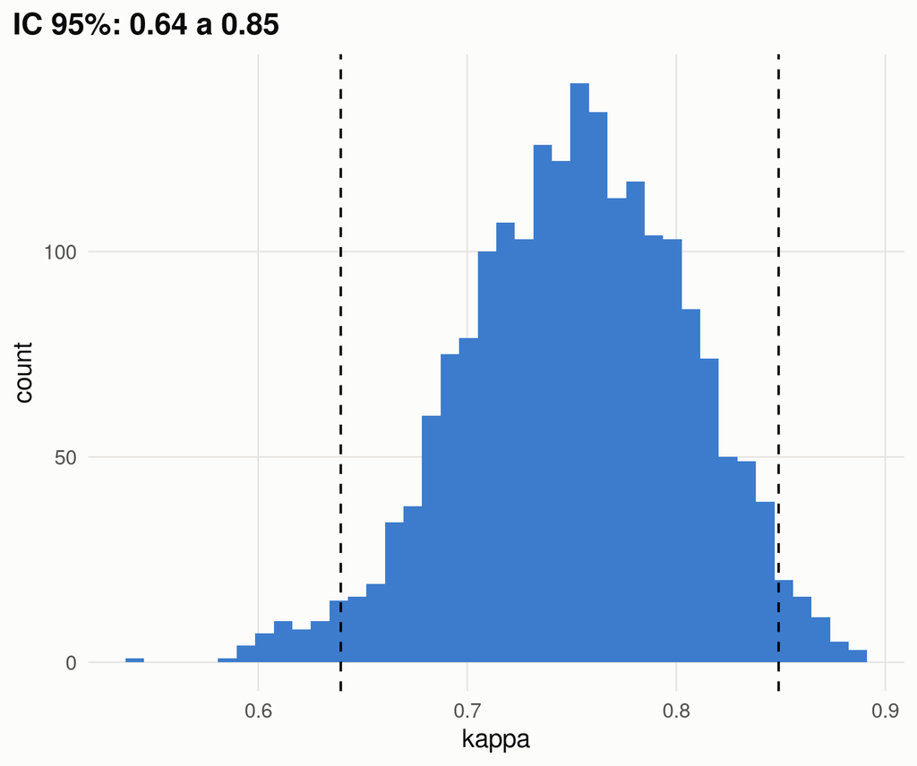

```r
d <- filter(aval, instrumento == "LLM v2 (t=0)")
set.seed(2026)
boot <- replicate(2000, {
  i <- sample.int(nrow(d), replace = TRUE)
  kappa_cohen(d$categoria[i], d$categoria_llm[i])
})
ic <- quantile(boot, c(.025, .975))
ggplot(tibble(kappa = boot), aes(kappa)) +
  geom_histogram(bins = 40, fill = AZUIS[2]) +
  geom_vline(xintercept = ic, linetype = 2) +
  labs(title = paste("IC 95%:",
    round(ic[1], 2), "a", round(ic[2], 2))) +
  tema_minicurso(11)
```

## A tabela de validade

```r
metricas_llm <- aval |>
  group_by(instrumento) |>
  group_modify(\(d, ...) {
    ic <- boot_ic(d$categoria, d$categoria_llm)
    resumo_metricas(d$categoria, d$categoria_llm) |> mutate(kappa_li = ic[1], kappa_ls = ic[2])
  }) |> ungroup()
base_l <- tibble(doc_id = ouro$doc_id, categoria = ouro$categoria,
                 pred_dic = ouro$pred_dic, pred_ml = pred_ml)
metricas_base <- bind_rows(
  "Dicionário (regex)" = resumo_metricas(base_l$categoria, base_l$pred_dic) |>
    mutate(kappa_li = boot_ic(base_l$categoria, base_l$pred_dic)[1],
           kappa_ls = boot_ic(base_l$categoria, base_l$pred_dic)[2]),
  "TF-IDF + logística (CV 10)" = resumo_metricas(base_l$categoria, base_l$pred_ml) |>
    mutate(kappa_li = boot_ic(base_l$categoria, base_l$pred_ml)[1],
           kappa_ls = boot_ic(base_l$categoria, base_l$pred_ml)[2]),
  .id = "instrumento")
metricas <- bind_rows(metricas_base, metricas_llm) |> arrange(desc(kappa))
```

## A tabela de validade: o resultado

```r
metricas |> select(-n) |> mutate(across(where(is.double), \(x) round(x, 2))) |> print(width = 110)
```

```
#> # A tibble: 8 × 7
#>   instrumento                falhas_formato acuracia f1_macro kappa kappa_li kappa_ls
#>   <chr>                               <dbl>    <dbl>    <dbl> <dbl>    <dbl>    <dbl>
#> 1 LLM v2 (t=0)                            0     0.85     0.79  0.75     0.64     0.85
#> 2 LLM v3 (t=0)                            0     0.84     0.79  0.75     0.65     0.85
#> 3 LLM v2 (t=0.8, s=1)                     0     0.83     0.76  0.73     0.61     0.82
#> 4 LLM v2 (t=0.8, s=2)                     0     0.83     0.76  0.73     0.61     0.82
#> 5 LLM v2 (t=0.8, s=3)                     0     0.83     0.76  0.73     0.61     0.82
#> 6 Dicionário (regex)                      0     0.81     0.78  0.7      0.59     0.81
#> 7 LLM v1 (t=0)                            0     0.72     0.55  0.52     0.38     0.65
#> 8 TF-IDF + logística (CV 10)              0     0.68     0.5   0.41     0.26     0.54
```

## Confere com o pipeline?

```r
oficial <- read_csv("resultados/tabelas/validade_instrumentos.csv")
inner_join(select(metricas, instrumento, kappa, kappa_li, kappa_ls),
           select(oficial, instrumento, kappa_pipeline = kappa, li_pipeline = kappa_li),
           by = "instrumento") |>
  mutate(across(where(is.double), \(x) round(x, 3)))
```

```
#> # A tibble: 8 × 6
#>   instrumento                kappa kappa_li kappa_ls kappa_pipeline li_pipeline
#>   <chr>                      <dbl>    <dbl>    <dbl>          <dbl>       <dbl>
#> 1 LLM v2 (t=0)               0.753    0.64     0.849          0.753       0.64
#> 2 LLM v3 (t=0)               0.75     0.645    0.846          0.75        0.645
#> 3 LLM v2 (t=0.8, s=1)        0.727    0.614    0.823          0.727       0.614
#> 4 LLM v2 (t=0.8, s=2)        0.727    0.614    0.823          0.727       0.614
#> 5 LLM v2 (t=0.8, s=3)        0.727    0.614    0.823          0.727       0.614
#> 6 Dicionário (regex)         0.699    0.586    0.809          0.699       0.586
#> 7 LLM v1 (t=0)               0.524    0.378    0.649          0.524       0.378
#> 8 TF-IDF + logística (CV 10) 0.407    0.262    0.543          0.407       0.262
```

Mesmas sementes, mesmos números.

## Validade: a figura

```r
melhor <- metricas_llm |> filter(str_detect(instrumento, "t=0\\)")) |>
  slice_max(kappa, n = 1) |> pull(instrumento)

metricas |>
  mutate(instrumento = reorder(instrumento, kappa),
         tipo = if_else(str_detect(instrumento, "^LLM"), "LLM (S5-nano instruct, local)", "Baseline clássico")) |>
  ggplot(aes(kappa, instrumento, colour = tipo)) +
  geom_vline(xintercept = c(.4, .6, .8), colour = GRADE, linetype = 2) +
  geom_linerange(aes(xmin = kappa_li, xmax = kappa_ls), linewidth = 2) +
  geom_point(size = 3.5) +
  scale_colour_manual(values = c("Baseline clássico" = CINZA, "LLM (S5-nano instruct, local)" = AZUIS[3])) +
  scale_x_continuous(limits = c(0, 1)) +
  labs(title = "Validade: concordância de cada instrumento com a amostra-ouro",
       subtitle = "Kappa de Cohen com IC 95% bootstrap (n = 120 ementas)",
       x = "Kappa de Cohen", y = NULL, colour = NULL) +
  tema_minicurso()
```

## Validade: a figura

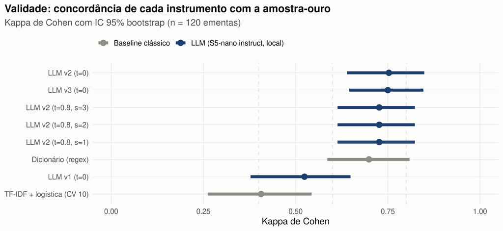

## Três leituras da tabela

1. **O prompt importa:** o melhor LLM (LLM v2 (t=0), kappa 0,75) supera a versão sem definições (v1, kappa 0,52)
2. **LLM × dicionário:** kappa 0,75 × 0,70, com **intervalos sobrepostos**: com 120 ementas, não há evidência de diferença. E o dicionário viu a prova
3. **LLM × TF-IDF:** o modelo clássico (0,41) precisaria de muito mais exemplos rotulados

## Onde o instrumento erra

```r
erro <- aval |> filter(instrumento == melhor)
table(humano = factor(erro$categoria, levels = CATEGORIAS), llm = erro$categoria_llm)
```

```
#>           llm
#> humano     PUNIR REGULAR PROMOVER OUTRO
#>   PUNIR       22       0        0     0
#>   REGULAR      4      61        4     0
#>   PROMOVER     0       2       13     1
#>   OUTRO        0       5        2     6
```

```r
erro |> count(humano = categoria, llm = categoria_llm) |> filter(humano != llm) |> arrange(desc(n))
```

```
#> # A tibble: 6 × 3
#>   humano   llm          n
#>   <chr>    <fct>    <int>
#> 1 OUTRO    REGULAR      5
#> 2 REGULAR  PUNIR        4
#> 3 REGULAR  PROMOVER     4
#> 4 OUTRO    PROMOVER     2
#> 5 PROMOVER REGULAR      2
#> 6 PROMOVER OUTRO        1
```

Erros não são iguais: confundir REGULAR com PUNIR **infla** a proporção punitiva que vamos estimar; confundir REGULAR com PROMOVER não a afeta.

## Matriz de confusão: a figura

```r
conf <- erro |>
  count(humano = factor(categoria, levels = CATEGORIAS), llm = categoria_llm, .drop = FALSE) |>
  group_by(humano) |> mutate(prop = n / sum(n)) |> ungroup()
ggplot(conf, aes(llm, humano, fill = prop)) +
  geom_tile(colour = "#fcfcfb", linewidth = 1.5) +
  geom_text(aes(label = n, colour = prop > .5), size = 5) +
  scale_colour_manual(values = c(`TRUE` = "white", `FALSE` = TINTA), guide = "none") +
  scale_fill_gradient(low = "#eef4fc", high = AZUIS[3], limits = c(0, 1), labels = scales::percent) +
  scale_y_discrete(limits = rev) +
  labs(title = paste("Onde o instrumento erra:", melhor),
       subtitle = "Linhas: codificação humana · Colunas: LLM · Cor: % da linha",
       x = "Rótulo do LLM", y = "Rótulo humano", fill = "% da linha") +
  tema_minicurso()
```

## Matriz de confusão: a figura

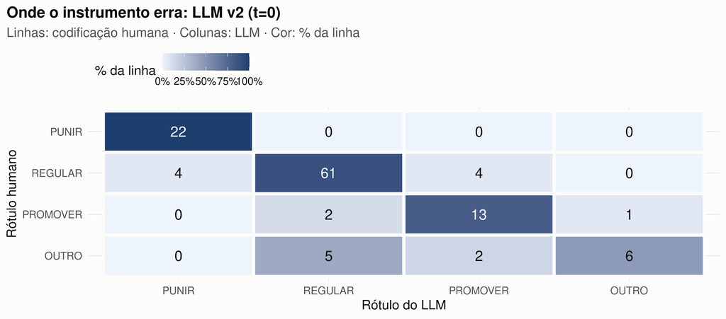

## As ementas que o LLM errou

```r
erro |>
  filter(as.character(categoria) != as.character(categoria_llm)) |>
  left_join(select(corpus, doc_id, ementa), by = "doc_id") |>
  transmute(doc_id, humano = categoria, llm = categoria_llm, ementa = str_trunc(ementa, 95)) |>
  head(8) |>
  knitr::kable()
```

| doc_id | humano | llm | ementa |
| --- | --- | --- | --- |
| doc0013 | REGULAR | PUNIR | Altera a Lei nº 9.504, de 30 de setembro de 1997, que estabelece normas para as eleições, pa… |
| doc0020 | REGULAR | PROMOVER | Dispõe sobre a criação do Fundo de Renda Básica, que será utilizado para redistribuição de r… |
| doc0034 | REGULAR | PUNIR | Altera a Lei nº 9.504, de 30 de setembro de 1997, para dispor sobre a vedação à criação, uti… |
| doc0045 | REGULAR | PUNIR | Proíbe o uso de Aplicativos e Programas de Inteligência Artificial para criação de “Deep Nud… |
| doc0073 | PROMOVER | REGULAR | Dispõe sobre a utilização de ferramentas tecnológicas de inteligência artificial para gestão… |
| doc0105 | OUTRO | REGULAR | Altera a Lei nº 9.610, de 19 de fevereiro de 1998 (Lei de Direitos Autorais), para modificar… |
| doc0106 | PROMOVER | OUTRO | Altera a Política Nacional de Busca de Pessoas Desaparecidas incorporando o uso da tecnologi… |
| doc0169 | REGULAR | PROMOVER | Dispõe sobre o aprimoramento das ações de fomento à escrita humana, ao pensamento crítico e … |

**Pergunta para a turma:** em quais destes o LLM tem razão e a referência deveria ser revista?

## Viés diferencial: a ideia

Acurácia alta **na média** não garante comparações válidas **entre grupos**.

- Se o LLM erra mais nas ementas de um campo político, qualquer comparação **entre campos** feita com seus rótulos estará enviesada
- Isso é relevante porque o **viés político** de LLMs está documentado (Motoki et al., 2024; Rozado, 2024)
- O que medir por grupo: **acurácia** e, principalmente, o **viés na quantidade que vamos estimar** (proporção PUNIR do LLM − do humano)

## Viés por campo político

```r
dif <- erro |>
  left_join(select(corpus, doc_id, campo, casa), by = "doc_id") |>
  mutate(punir_h = categoria == "PUNIR", punir_l = categoria_llm %in% "PUNIR",
         acerto  = as.character(categoria) == as.character(categoria_llm))
vies_campo <- dif |>
  filter(campo != "Sem partido/Outro") |>
  group_by(campo) |>
  summarise(n = n(), acuracia = mean(acerto), prop_punir_humano = mean(punir_h),
            prop_punir_llm = mean(punir_l), vies_punir = prop_punir_llm - prop_punir_humano) |>
  mutate(ep = sqrt(acuracia * (1 - acuracia) / n), li = acuracia - 1.96 * ep, ls = acuracia + 1.96 * ep)
vies_campo |> mutate(across(where(is.double), \(x) round(x, 3)))
```

```
#> # A tibble: 3 × 9
#>   campo        n acuracia prop_punir_humano prop_punir_llm vies_punir    ep    li    ls
#>   <chr>    <int>    <dbl>             <dbl>          <dbl>      <dbl> <dbl> <dbl> <dbl>
#> 1 Centro      31    0.806             0.161          0.194      0.032 0.071 0.667 0.946
#> 2 Direita     52    0.827             0.154          0.192      0.038 0.052 0.724 0.93
#> 3 Esquerda    33    0.909             0.182          0.212      0.03  0.05  0.811 1.01
```

## Viés diferencial: a figura

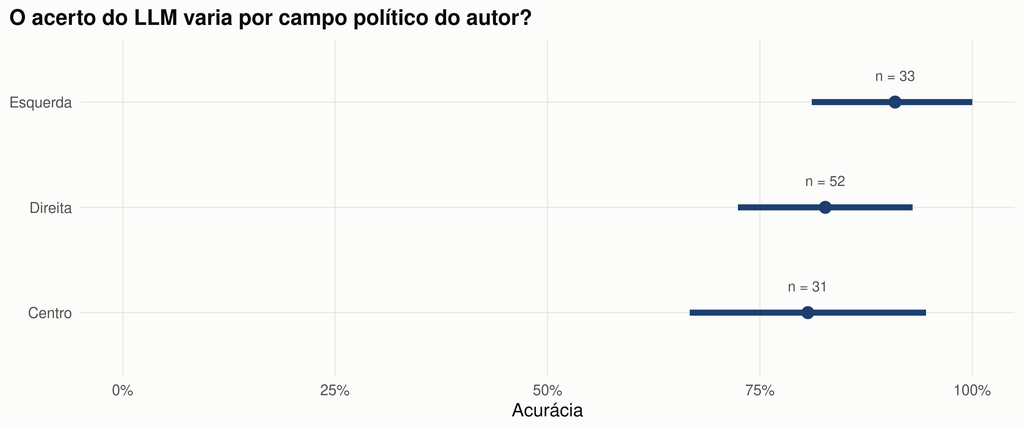

```r
ggplot(vies_campo, aes(acuracia, reorder(campo, acuracia))) +
  geom_linerange(aes(xmin = pmax(li, 0), xmax = pmin(ls, 1)), linewidth = 2, colour = AZUIS[3]) +
  geom_point(size = 3.5, colour = AZUIS[3]) +
  geom_text(aes(label = paste0("n = ", n)), nudge_y = .25, size = 3.5, colour = TINTA2) +
  scale_x_continuous(limits = c(0, 1), labels = scales::percent) +
  labs(title = "O acerto do LLM varia por campo político do autor?", x = "Acurácia", y = NULL) +
  tema_minicurso()
```

## Um teste formal

```r
mod <- glm(acerto ~ campo, family = binomial, data = filter(dif, campo != "Sem partido/Outro"))
anova(mod, test = "Chisq")
```

```
#> Analysis of Deviance Table
#>
#> Model: binomial, link: logit
#>
#> Response: acerto
#>
#> Terms added sequentially (first to last)
#>
#>
#>       Df Deviance Resid. Df Resid. Dev Pr(>Chi)
#> NULL                    115    100.126
#> campo  2   1.6415       113     98.484   0.4401
```

**Nota**

Não rejeitar não é o mesmo que **descartar** o viés: com 31 a 52 ementas por campo, o teste tem pouco poder. A lição: **com esta amostra-ouro, não é possível descartar viés diferencial**.

## Confiabilidade: o instrumento é estável?

Duas fontes de instabilidade, **sem precisar de rótulo humano**:

- **Teste-reteste:** mesmo prompt (v2), mesma ementa, temperatura 0,8, **três sementes**
- **Sensibilidade ao prompt:** mesmo modelo, temperatura 0, **três redações** (v1, v2, v3)

**Alfa de Krippendorff** (nominal): generaliza o kappa para $k$ codificadores e aceita faltantes

$$\alpha = 1 - \frac{D_o}{D_e} \qquad D_o: \text{discordância observada} \quad D_e: \text{esperada ao acaso}$$

## O alfa num exemplo pequeno

Três codificadores fictícios, seis ementas:

```r
m <- rbind(c("PUNIR",   "PUNIR",   "PUNIR"),
           c("REGULAR", "REGULAR", "PROMOVER"),
           c("REGULAR", "REGULAR", "REGULAR"),
           c("OUTRO",   "OUTRO",   NA),
           c("PROMOVER","REGULAR", "PROMOVER"),
           c("REGULAR", "REGULAR", "REGULAR"))
alfa_krippendorff(m)
```

```
#> [1] 0.655914
```

```r
alfa_krippendorff(m[, 1:2])
```

```
#> [1] 0.744186
```

`m` é a matriz de rótulos (ementas × codificadores). Dentro de `alfa_krippendorff()`, ela vira a matriz de **coincidências**, que conta pares de rótulos dentro de cada ementa; a diagonal são concordâncias. Sem o terceiro codificador, a concordância muda.

## Teste-reteste: trocar a semente

```r
largo_seed <- llm |>
  filter(prompt_id == "v2", temperatura > 0) |>
  select(doc_id, semente, categoria_llm) |>
  mutate(categoria_llm = as.character(categoria_llm)) |>
  tidyr::pivot_wider(names_from = semente, values_from = categoria_llm, names_prefix = "s")
head(largo_seed, 4)
```

```
#> # A tibble: 4 × 4
#>   doc_id  s1      s2      s3
#>   <chr>   <chr>   <chr>   <chr>
#> 1 doc0001 REGULAR REGULAR REGULAR
#> 2 doc0002 REGULAR REGULAR REGULAR
#> 3 doc0003 REGULAR REGULAR REGULAR
#> 4 doc0004 REGULAR REGULAR REGULAR
```

```r
alfa_reteste <- alfa_krippendorff(select(largo_seed, -doc_id))
muda_seed <- mean(apply(select(largo_seed, -doc_id), 1, \(x) n_distinct(na.omit(x)) > 1))
c(alfa = alfa_reteste, prop_que_muda = muda_seed)
```

```
#>          alfa prop_que_muda
#>             1             0
```

## Sensibilidade ao prompt: trocar a redação

```r
largo_prompt <- llm |>
  filter(temperatura == 0, semente == 42) |>
  select(doc_id, prompt_id, categoria_llm) |>
  mutate(categoria_llm = as.character(categoria_llm)) |>
  tidyr::pivot_wider(names_from = prompt_id, values_from = categoria_llm)
alfa_prompt <- alfa_krippendorff(select(largo_prompt, -doc_id))
muda_prompt <- mean(apply(select(largo_prompt, -doc_id), 1, \(x) n_distinct(na.omit(x)) > 1))
tibble(comparacao = c("Teste-reteste (v2, t=0,8, 3 sementes)", "Sensibilidade ao prompt (v1, v2, v3; t=0)"),
       alfa = c(alfa_reteste, alfa_prompt), prop_ementas_que_mudam = c(muda_seed, muda_prompt))
```

```
#> # A tibble: 2 × 3
#>   comparacao                                 alfa prop_ementas_que_mudam
#>   <chr>                                     <dbl>                  <dbl>
#> 1 Teste-reteste (v2, t=0,8, 3 sementes)     1                      0
#> 2 Sensibilidade ao prompt (v1, v2, v3; t=0) 0.746                  0.234
```

**Importante**

**O prompt importa muito mais que o acaso:** trocar a semente muda 0% das ementas; trocar o prompt muda 23%.

## Ementas que mudam com o prompt

```r
largo_prompt |>
  filter(v1 != v2 | v2 != v3) |>
  left_join(select(corpus, doc_id, ementa), by = "doc_id") |>
  left_join(select(ref, doc_id, ref = categoria), by = "doc_id") |>
  transmute(doc_id, v1, v2, v3, ref, ementa = str_trunc(ementa, 70)) |>
  head(8) |> knitr::kable()
```

| doc_id | v1 | v2 | v3 | ref | ementa |
| --- | --- | --- | --- | --- | --- |
| doc0004 | OUTRO | REGULAR | OUTRO | REGULAR | Dispõe sobre o uso da Inteligência Artificial. |
| doc0007 | REGULAR | PROMOVER | PROMOVER | REGULAR | Dispõe sobre a compatibilização dos sistemas de Inteligência Artifi… |
| doc0009 | PROMOVER | PROMOVER | OUTRO | OUTRO | Institui a Política Nacional de Educação Digital; altera as Leis nº… |
| doc0010 | REGULAR | OUTRO | OUTRO | OUTRO | Dispõe sobre a reforma da Lei nº 9.784/99 (Lei de Processo Administ… |
| doc0012 | REGULAR | PROMOVER | PROMOVER | PROMOVER | Estabelece procedimentos a serem adotados pela União em regime de c… |
| doc0013 | REGULAR | PUNIR | PUNIR | REGULAR | Altera a Lei nº 9.504, de 30 de setembro de 1997, que estabelece no… |
| doc0014 | REGULAR | REGULAR | PROMOVER | REGULAR | Dispõe sobre normas gerais para a pesquisa, o desenvolvimento e a a… |
| doc0018 | OUTRO | REGULAR | OUTRO | REGULAR | Dispõe sobre o uso da Inteligência Artificial. |

## A medida agregada também muda

```r
dist_all <- bind_rows(
  llm |> filter(temperatura == 0, semente == 42) |> count(fonte = prompt_id, categoria = categoria_llm),
  ref |> count(categoria = factor(categoria, levels = CATEGORIAS)) |> mutate(fonte = "Referência\nhumana")) |>
  group_by(fonte) |> mutate(prop = n / sum(n)) |> ungroup() |>
  mutate(fonte = factor(fonte, levels = c("v1", "v2", "v3", "Referência\nhumana")))

ggplot(dist_all, aes(prop, fonte, fill = fonte)) +
  geom_col(width = .7) +
  facet_wrap(~categoria, nrow = 1) +
  scale_fill_manual(values = c(v1 = AZUIS[1], v2 = AZUIS[2], v3 = AZUIS[3], "Referência\nhumana" = CINZA),
                    guide = "none") +
  scale_x_continuous(labels = scales::percent, breaks = c(0, .3, .6)) +
  scale_y_discrete(limits = rev) +
  labs(title = "Mesmo modelo, mesmos textos, prompts diferentes: medidas diferentes",
       x = NULL, y = NULL) +
  tema_minicurso() + theme(panel.grid.major.y = element_blank())
```

## A medida agregada também muda

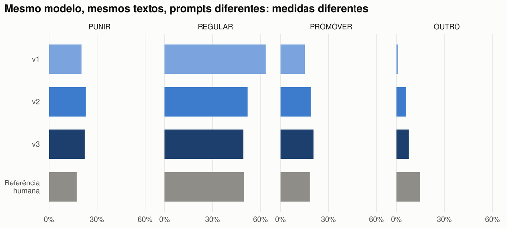

## A variável eleitoral

```r
llm |> filter(temperatura == 0, semente == 42) |>
  inner_join(select(ouro, doc_id, eleitoral), by = "doc_id") |>
  group_by(prompt_id) |>
  summarise(eleitorais_humano = sum(eleitoral), eleitorais_llm = sum(eleitoral_llm, na.rm = TRUE),
            sensibilidade  = mean(eleitoral_llm[eleitoral == 1], na.rm = TRUE),
            especificidade = mean(!eleitoral_llm[eleitoral == 0], na.rm = TRUE))
```

```
#> # A tibble: 3 × 5
#>   prompt_id eleitorais_humano eleitorais_llm sensibilidade especificidade
#>   <chr>                 <dbl>          <int>         <dbl>          <dbl>
#> 1 v1                        8              8             1              1
#> 2 v2                        8              8             1              1
#> 3 v3                        8              8             1              1
```

Variável **rara**: acurácia não informa quase nada.

**Sensibilidade** (dos eleitorais, quantos o LLM achou?) e

**especificidade** (dos não eleitorais, quantos descartou?).

Com tão poucos casos eleitorais, a sensibilidade é muito imprecisa.

## Humano × humano: a comparação que falta

Quando a referência for revisada por **dois codificadores humanos**, este trecho calcula o alfa entre eles:

```r
arqs <- list.files("material_apoio/respostas", "\\.csv$", full.names = TRUE)
resp <- map(arqs, \(a) read_csv(a) |> mutate(codificador = tools::file_path_sans_ext(basename(a)))) |>
  list_rbind() |>
  mutate(categoria = str_to_upper(str_trim(categoria)))
m <- resp |> select(doc_id, codificador, categoria) |>
  tidyr::pivot_wider(names_from = codificador, values_from = categoria)
alfa_krippendorff(select(m, -doc_id))     # alfa entre os codificadores
```

**A comparação mais honesta**

O LLM concorda com a referência **tanto quanto os humanos concordam entre si**? Neste material a referência é de outra IA, então essa resposta ainda **não existe**.

**Pergunta para a turma**

O kappa do S5-nano contra a referência é alto ou baixo? **Comparado a quê?**

## Síntese da validação

**Executamos**

- métricas e IC bootstrap de 8 instrumentos
- matriz de confusão e erros
- viés por campo e teste logístico
- alfa entre sementes e entre prompts

**O que sabemos do instrumento**

- concordância **substancial** com a referência
- **estável** entre sementes
- **sensível ao prompt**
- viés diferencial **não descartado**

→ bom, mas **imperfeito**. Como usá-lo sem esconder isso?

# 6 · Inferência com rótulos imperfeitos

## O que vamos executar neste bloco

1. Montar, para cada ementa, o rótulo do **LLM** ($f$) e o **humano** ($y$, só na amostra-ouro)
2. Quatro estimadores da proporção PUNIR: **só humanos**, **ingênuo**, **PPI** e **PPI++**
3. Conferir quem acerta o valor da referência completa
4. Uma **simulação**: 1.000 amostras-ouro para cada tamanho, e a **cobertura** dos ICs
5. A mesma pergunta **por campo político**

## O problema

Queremos $\theta$ = proporção de projetos **PUNIR**. Temos:

- a **amostra-ouro**: $n$ = 120 ementas com rótulo humano $Y_j$ **e** do LLM $f(X_j)$
- as outras $N$ = 184 ementas, só com o rótulo do LLM $f(X_i)$

“Humano” = o rótulo de referência. Neste material ele ainda é preliminar e veio de outra IA; o método é o mesmo quando a referência for revisada por humanos.

**Só humanos**
$$\hat\theta_H = \bar Y_n$$
sem viés, mas **impreciso**

**Ingênuo**
$$\hat\theta_{LLM} = \bar f_{N+n}$$
preciso, mas **enviesado** pelo erro do LLM

## Montando $y$ e $f$

```r
PROMPT <- str_extract(melhor, "v\\d")
dados <- corpus |>
  select(doc_id, ano, campo, casa) |>
  left_join(llm |> filter(prompt_id == PROMPT, temperatura == 0, semente == 42) |>
              select(doc_id, categoria_llm), by = "doc_id") |>
  left_join(select(ref, doc_id, categoria_ref = categoria), by = "doc_id") |>
  mutate(na_ouro = doc_id %in% ouro$doc_id,
         f = as.integer(categoria_llm %in% "PUNIR"),                        # LLM: 0/1
         y = if_else(na_ouro, as.integer(categoria_ref == "PUNIR"), NA_integer_))  # humano: 0/1 ou NA
dados |> select(doc_id, campo, categoria_llm, na_ouro, f, y) |> head(6)
```

```
#> # A tibble: 6 × 6
#>   doc_id  campo             categoria_llm na_ouro     f     y
#>   <chr>   <chr>             <fct>         <lgl>   <int> <int>
#> 1 doc0001 Direita           REGULAR       TRUE        0     0
#> 2 doc0002 Direita           REGULAR       FALSE       0    NA
#> 3 doc0003 Direita           REGULAR       TRUE        0     0
#> 4 doc0004 Centro            REGULAR       TRUE        0     0
#> 5 doc0005 Esquerda          REGULAR       FALSE       0    NA
#> 6 doc0006 Sem partido/Outro REGULAR       FALSE       0    NA
```

```r
lab <- filter(dados, na_ouro); unl <- filter(dados, !na_ouro)
c(n = nrow(lab), N = nrow(unl))
```

```
#>   n   N
#> 120 184
```

## O “valor verdadeiro” (só porque é didático)

```r
verdade <- mean(ref$categoria == "PUNIR")
verdade
```

```
#> [1] 0.1743421
```

**Nota**

Este corpus tem referência para **todas** as 304 ementas, então conhecemos $\theta$ = 17,4%. Numa pesquisa real, **não** conhecemos: por isso precisamos de estimadores com IC honesto. Aqui, podemos **conferir** quem acerta.

## (a) Só humanos

```r
est_humano <- function(y_n) ic_normal(mean(y_n), sd(y_n) / sqrt(length(y_n)))
```

```r
est_humano(lab$y)
```

```
#> # A tibble: 1 × 4
#>   estimativa     ep    li    ls
#>        <dbl>  <dbl> <dbl> <dbl>
#> 1      0.183 0.0355 0.114 0.253
```

Média da amostra-ouro, com erro-padrão $\sqrt{\hat p(1 - \hat p)/n}$. Desperdiça a informação das outras 184 ementas.

## (b) Ingênuo: o LLM como verdade

```r
est_ingenuo(c(lab$f, unl$f))
```

```
#> # A tibble: 1 × 4
#>   estimativa     ep    li    ls
#>        <dbl>  <dbl> <dbl> <dbl>
#> 1      0.230 0.0242 0.183 0.278
```

Por que ele erra? Na amostra-ouro, temos **os dois** rótulos:

```r
c(LLM = mean(lab$f), humano = mean(lab$y), vies_estimado = mean(lab$f) - mean(lab$y))
```

```
#>           LLM        humano vies_estimado
#>    0.21666667    0.18333333    0.03333333
```

```r
table(humano = lab$y, llm = lab$f)
```

```
#>       llm
#> humano  0  1
#>      0 94  4
#>      1  0 22
```

O LLM marca PUNIR em ementas que o humano não marca: os **falsos positivos** inflam a proporção. E o IC do ingênuo **ignora** esse erro.

## (c) *Prediction-Powered Inference*

Use a amostra-ouro para **medir o viés do LLM** e subtraia (Angelopoulos et al., *Science*, 2023):

$$\hat\theta_{PP} = \underbrace{\frac{1}{N}\sum_{i=1}^{N} f(X_i)}_{\text{LLM no não rotulado}} \; - \; \underbrace{\frac{1}{n}\sum_{j=1}^{n}\big(f(X_j) - Y_j\big)}_{\text{viés do LLM medido na amostra-ouro (retificador)}}$$

$$\widehat{\text{Var}}(\hat\theta_{PP}) = \frac{\hat\sigma^2_{f}}{N} + \frac{\hat\sigma^2_{f-Y}}{n}$$

- **Nenhuma hipótese** sobre a qualidade do LLM: um LLM ruim gera retificador com variância alta → **IC largo**, não **IC errado**

## PPI em cinco linhas

```r
est_ppi <- function(y_n, f_n, f_N) {
  retificador <- f_n - y_n
  est <- mean(f_N) - mean(retificador)
  ep <- sqrt(var(f_N) / length(f_N) + var(retificador) / length(y_n))
  ic_normal(est, ep)
}
```

```r
est_ppi(lab$y, lab$f, unl$f)
```

```
#> # A tibble: 1 × 4
#>   estimativa     ep    li    ls
#>        <dbl>  <dbl> <dbl> <dbl>
#> 1      0.206 0.0356 0.136 0.276
```

## PPI passo a passo

```r
retificador <- lab$f - lab$y
c(media_f_N   = mean(unl$f),
  vies        = mean(retificador),
  estimativa  = mean(unl$f) - mean(retificador),
  ep          = sqrt(var(unl$f) / nrow(unl) + var(retificador) / nrow(lab)))
```

```
#>  media_f_N       vies estimativa         ep
#> 0.23913043 0.03333333 0.20579710 0.03556714
```

O viés estimado é subtraído; o erro-padrão soma a incerteza do LLM no não rotulado e a do retificador na amostra-ouro.

## (d) PPI++: quanto confiar no LLM?

PPI++ (Angelopoulos, Duchi & Zrnic, 2023) pondera o LLM por $\lambda \in [0, 1]$, escolhido para **minimizar a variância**:

$$\hat\theta_{PP}^{\lambda} = \bar Y_n + \lambda\big(\bar f_N - \bar f_n\big), \qquad
\hat\lambda = \frac{\widehat{\text{Cov}}(Y, f)}{(1 + n/N)\,\widehat{\text{Var}}(f)}$$

- LLM inútil → $\hat\lambda \to 0$: volta a ser o “só humanos”
- LLM muito bom → $\hat\lambda \to 1$: aproxima-se do PPI

## PPI++ em R

```r
est_ppi_plus <- function(y_n, f_n, f_N) {
  n <- length(y_n); N <- length(f_N)
  f_todos <- c(f_n, f_N)
  lambda <- cov(y_n, f_n) / ((1 + n / N) * var(f_todos))
  lambda <- min(max(lambda, 0), 1)
  est <- mean(y_n) + lambda * (mean(f_N) - mean(f_n))
  ep <- sqrt(var(y_n - lambda * f_n) / n + lambda^2 * var(f_N) / N)
  ic_normal(est, ep) |> mutate(lambda = lambda)
}
```

```r
est_ppi_plus(lab$y, lab$f, unl$f)
```

```
#> # A tibble: 1 × 5
#>   estimativa     ep    li    ls lambda
#>        <dbl>  <dbl> <dbl> <dbl>  <dbl>
#> 1      0.194 0.0256 0.144 0.245  0.493
```

## Os quatro estimadores

```r
est <- compara_estimadores(lab$y, lab$f, unl$f) |>
  mutate(largura = ls - li, cobre_verdade = li <= verdade & verdade <= ls)
est |> mutate(across(where(is.double), \(x) round(x, 3)))
```

```
#> # A tibble: 4 × 8
#>   estimador                 estimativa    ep    li    ls lambda largura cobre_verdade
#>   <chr>                          <dbl> <dbl> <dbl> <dbl>  <dbl>   <dbl> <lgl>
#> 1 Só humanos (amostra-ouro)      0.183 0.035 0.114 0.253 NA       0.139 TRUE
#> 2 Ingênuo (LLM = verdade)        0.23  0.024 0.183 0.278 NA       0.095 FALSE
#> 3 PPI                            0.206 0.036 0.136 0.276 NA       0.139 TRUE
#> 4 PPI++                          0.194 0.026 0.144 0.245  0.493   0.1   TRUE
```

Valor na referência completa: **17,4%**. Conferência com o pipeline: estimativas idênticas às de resultados/tabelas/estimativas_punir.csv.

## A figura

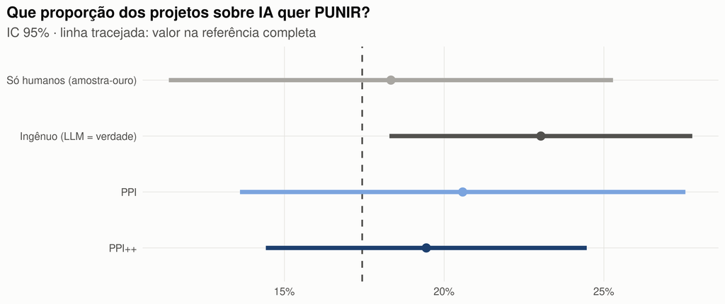

```r
est |>
  mutate(estimador = factor(estimador, levels = rev(unique(estimador)))) |>
  ggplot(aes(estimativa, estimador)) +
  geom_vline(xintercept = verdade, colour = CINZA_ESCURO, linewidth = .8, linetype = 2) +
  geom_linerange(aes(xmin = li, xmax = ls, colour = estimador), linewidth = 2) +
  geom_point(aes(colour = estimador), size = 3.5) +
  scale_colour_manual(values = COR_EST, guide = "none") +
  scale_x_continuous(labels = scales::percent) +
  labs(title = "Que proporção dos projetos sobre IA quer PUNIR?",
       subtitle = "IC 95% · linha tracejada: valor na referência completa", x = NULL, y = NULL) +
  tema_minicurso()
```

## Um resultado pode ser sorte

Um único sorteio da amostra-ouro não diz se o método é bom. Então:

1. Sorteie uma amostra-ouro de tamanho $n$ (30, 60 ou 120)
2. Calcule os quatro estimadores e seus ICs
3. Verifique se cada IC **contém** o valor verdadeiro
4. Repita **1.000 vezes**

**Cobertura** = proporção de repetições em que o IC contém a verdade. Um bom IC de 95% acerta em ~95%.

## A simulação em R

```r
simula <- function(n_ouro, B = 1000, semente = 1) {
  set.seed(semente)
  map(seq_len(B), \(b) {
    idx <- sample(nrow(dados), n_ouro)                         # nova amostra-ouro
    y_n <- as.integer(dados$categoria_ref[idx] == "PUNIR")
    compara_estimadores(y_n, dados$f[idx], dados$f[-idx])
  }) |>
    list_rbind() |>
    group_by(estimador) |>
    summarise(cobertura = mean(li <= verdade & verdade <= ls),
              largura_media = mean(ls - li), vies = mean(estimativa) - verdade) |>
    mutate(n_ouro = n_ouro)
}
tempo <- system.time(sim <- map(c(30, 60, 120), simula) |> list_rbind())
tempo[["elapsed"]]
```

```
#> [1] 8.845
```

## Cobertura e largura

```r
sim |>
  mutate(across(c(cobertura, largura_media, vies), \(x) round(x, 3))) |>
  select(n_ouro, estimador, cobertura, largura_media, vies) |>
  arrange(n_ouro) |>
  print(n = 12)
```

```
#> # A tibble: 12 × 5
#>    n_ouro estimador                 cobertura largura_media   vies
#>     <dbl> <chr>                         <dbl>         <dbl>  <dbl>
#>  1     30 Ingênuo (LLM = verdade)       0             0.095  0.056
#>  2     30 PPI                           0.841         0.184  0.003
#>  3     30 PPI++                         0.866         0.156 -0.013
#>  4     30 Só humanos (amostra-ouro)     0.896         0.263 -0.006
#>  5     60 Ingênuo (LLM = verdade)       0             0.095  0.056
#>  6     60 PPI                           0.972         0.156  0.002
#>  7     60 PPI++                         0.962         0.124 -0.005
#>  8     60 Só humanos (amostra-ouro)     0.968         0.19  -0.003
#>  9    120 Ingênuo (LLM = verdade)       0             0.095  0.056
#> 10    120 PPI                           0.991         0.147  0.001
#> 11    120 PPI++                         0.997         0.102 -0.002
#> 12    120 Só humanos (amostra-ouro)     0.988         0.135 -0.002
```

## O IC ingênuo engana

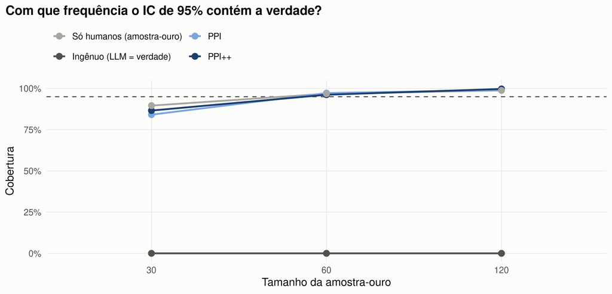

```r
sim |>
  mutate(estimador = factor(estimador, levels = unique(est$estimador))) |>
  ggplot(aes(factor(n_ouro), cobertura, colour = estimador, group = estimador)) +
  geom_hline(yintercept = .95, colour = TINTA2, linetype = 2) +
  geom_line(linewidth = 1) + geom_point(size = 3) +
  scale_colour_manual(values = COR_EST) +
  scale_y_continuous(labels = scales::percent, limits = c(0, 1)) +
  labs(title = "Com que frequência o IC de 95% contém a verdade?",
       x = "Tamanho da amostra-ouro", y = "Cobertura", colour = NULL) +
  guides(colour = guide_legend(nrow = 2)) + tema_minicurso()
```

## O preço da honestidade

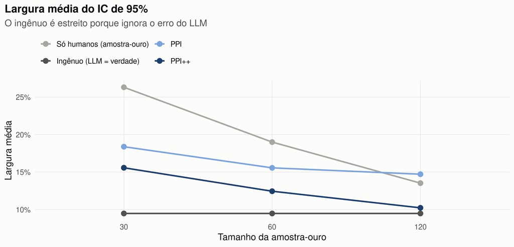

```r
sim |>
  mutate(estimador = factor(estimador, levels = unique(est$estimador))) |>
  ggplot(aes(factor(n_ouro), largura_media, colour = estimador, group = estimador)) +
  geom_line(linewidth = 1) + geom_point(size = 3) +
  scale_colour_manual(values = COR_EST) +
  scale_y_continuous(labels = scales::percent) +
  labs(title = "Largura média do IC de 95%",
       subtitle = "O ingênuo é estreito porque ignora o erro do LLM",
       x = "Tamanho da amostra-ouro", y = "Largura média", colour = NULL) +
  guides(colour = guide_legend(nrow = 2)) + tema_minicurso()
```

## E entre campos políticos?

```r
por_campo <- dados |>
  filter(campo %in% c("Esquerda", "Centro", "Direita")) |>
  group_by(campo) |>
  group_modify(\(d, ...) {
    l <- filter(d, na_ouro); u <- filter(d, !na_ouro)
    compara_estimadores(l$y, l$f, u$f) |>
      mutate(n_ouro = nrow(l), verdade = mean(d$categoria_ref == "PUNIR"))
  }) |> ungroup()
por_campo |> select(campo, estimador, n_ouro, estimativa, li, ls, verdade) |>
  mutate(across(where(is.double), \(x) round(x, 3))) |> print(n = 12)
```

```
#> # A tibble: 12 × 7
#>    campo    estimador                 n_ouro estimativa    li    ls verdade
#>    <chr>    <chr>                      <int>      <dbl> <dbl> <dbl>   <dbl>
#>  1 Centro   Só humanos (amostra-ouro)     31      0.161 0.03  0.293   0.131
#>  2 Centro   Ingênuo (LLM = verdade)       31      0.23  0.123 0.336   0.131
#>  3 Centro   PPI                           31      0.234 0.061 0.407   0.131
#>  4 Centro   PPI++                         31      0.188 0.082 0.294   0.131
#>  5 Direita  Só humanos (amostra-ouro)     52      0.154 0.055 0.253   0.174
#>  6 Direita  Ingênuo (LLM = verdade)       52      0.219 0.154 0.285   0.174
#>  7 Direita  PPI                           52      0.195 0.097 0.292   0.174
#>  8 Direita  PPI++                         52      0.174 0.103 0.245   0.174
#>  9 Esquerda Só humanos (amostra-ouro)     33      0.182 0.048 0.315   0.188
#> 10 Esquerda Ingênuo (LLM = verdade)       33      0.225 0.133 0.317   0.188
#> 11 Esquerda PPI                           33      0.204 0.068 0.34    0.188
#> 12 Esquerda PPI++                         33      0.193 0.096 0.29    0.188
```

## Por campo: a figura

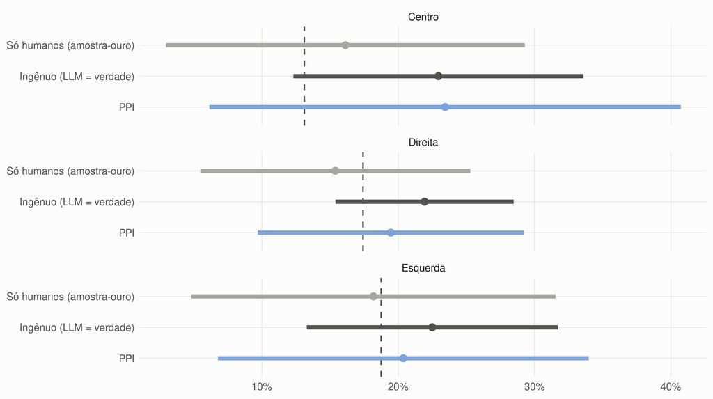

```r
por_campo |>
  filter(estimador != "PPI++") |>
  mutate(estimador = factor(estimador, levels = c("Só humanos (amostra-ouro)", "Ingênuo (LLM = verdade)", "PPI"))) |>
  ggplot(aes(estimativa, estimador, colour = estimador)) +
  geom_vline(aes(xintercept = verdade), colour = CINZA_ESCURO, linewidth = .7, linetype = 2) +
  geom_linerange(aes(xmin = pmax(li, 0), xmax = ls), linewidth = 2) +
  geom_point(size = 3) +
  facet_wrap(~ campo, ncol = 1) +
  scale_colour_manual(values = COR_EST, guide = "none") +
  scale_x_continuous(labels = scales::percent) + scale_y_discrete(limits = rev) +
  labs(x = NULL, y = NULL) + tema_minicurso()
```

## O que os números dizem

- **O ingênuo superestima** a proporção punitiva (23,0% × 17,4%) e seu IC cobriu a verdade em **0%** das simulações
- **PPI e PPI++ corrigem o viés**: cobertura de 99,1% e 99,7% com $n$ = 120
- **PPI++ é mais estreito** que o “só humanos”: 24% a menos de largura, em média
- Com $n$ = 30, todos ficam abaixo de 95%: amostras-ouro muito pequenas comprometem a aproximação normal
- **Por campo**, 31 a 52 ementas na ouro: intervalos largos e sobrepostos. **Não há evidência** de diferença entre campos

## A resposta substantiva

**Ilustrativa, enquanto a referência for preliminar**

Pelo **PPI++**, cerca de **19%** dos projetos sobre IA no Congresso querem **punir** (IC 95% de 14% a 24%). Cerca de metade **regula** (49% na referência).

E a resposta metodológica: **o LLM ajudou**, mas só porque medimos seu erro e o levamos para dentro do intervalo de confiança.

## Resumo do bloco 6

**Executamos**

- os quatro estimadores, passo a passo
- conferência com a referência completa
- simulação de cobertura (9 s)
- estimativas por campo político

**A lição**

- rótulo de LLM **não é** dado observado
- a amostra-ouro tem **dois papéis**: validar e **corrigir**
- relatar $n$ da amostra-ouro **em cada grupo**

# 7 · Reprodutibilidade (MLOps)

## O que vamos executar neste bloco

1. Listar **o que precisa ser versionado** numa pesquisa com LLM
2. Ler o pipeline declarativo em `_targets.R` e inspecioná-lo com `tar_manifest()`
3. Conferir, no cache, **a identidade do instrumento**: digest dos pesos, versão do Ollama, hash do prompt
4. Medir o *drift* de um modelo local: **repetir** as anotações a temperatura 0
5. Comparar as trilhas **R e Python**

## O que precisa ser versionado?

| Componente | Como versionar | Neste material |
| --- | --- | --- |
| Código | Git | `R/`, `python/` |
| Ambiente | `renv` / `requirements.txt` / Docker | `R/00_pacotes.R`, `requirements.txt`, `sessionInfo.txt` |
| Dados brutos | congelados, com data | `dados/bruto/`, `corpus.csv` (06/11/2026) |
| Instrumento | modelo (digest) + prompt (hash) + parâmetros | `modelos/`, `prompts/` + CHANGELOG |
| Respostas do LLM | cache (é dado, não lixo) | `dados/cache_llm/*.jsonl` |
| Referência humana | arquivo com codificador e revisão | `referencia_completa.csv` |

## Um pipeline declarativo: `_targets.R`

```r
list(
  tar_target(arq_corpus, "dados/processado/corpus.csv", format = "file"),
  tar_target(arq_prompts, list.files("prompts", "\\.txt$", full.names = TRUE), format = "file",
             cue = tar_cue(mode = "always")),
  tar_target(arq_cache_llm, list.files("dados/cache_llm", "\\.jsonl$", full.names = TRUE),
             format = "file", cue = tar_cue(mode = "always")),
  tar_target(amostra_ouro, roda_script("R/02_amostra_ouro.R", ..., arq_corpus, arq_referencia)),
  tar_target(baselines,    roda_script("R/03_baselines.R", ..., amostra_ouro)),
  tar_target(validacao,    roda_script("R/05_validacao.R", ..., baselines, arq_cache_llm, arq_prompts)),
  tar_target(inferencia,   roda_script("R/06_inferencia.R", ..., validacao))
)
```

Cada etapa declara **de que depende**. Coleta e anotação **não** entram como etapas (são caras e externas): entram como **arquivos versionados**.

## O grafo, lido pelo `targets`

```r
targets::tar_manifest(fields = c(name, command)) |>
  mutate(command = str_trunc(command, 80))
```

```
#> # A tibble: 11 × 2
#>   name           command
#>   <chr>          <chr>
#> 1 arq_scripts    "list.files(\"R\", \"^0[2-6]_.*\\\\.R$\", full.names = TRUE)"
#> 2 arq_funcoes    "c(\"R/funcoes_medicao.R\", \"R/tema_graficos.R\")"
#> 3 arq_prompts    "list.files(\"prompts\", \"\\\\.txt$\", full.names = TRUE)"
#> 4 arq_corpus     "\"dados/processado/corpus.csv\""
#> 5 arq_referencia "\"dados/anotacoes/referencia_completa.csv\""
#> 6 arq_cache_llm  "list.files(\"dados/cache_llm\", \"\\\\.jsonl$\", full.names = TRUE)"
#> # ℹ 5 more rows
```

## Rodando o pipeline

```r
targets::tar_make()        # roda só o que está desatualizado
targets::tar_outdated()    # editei o prompt v2... o que precisa ser refeito?
targets::tar_visnetwork()  # desenha o grafo (precisa do pacote visNetwork)
```

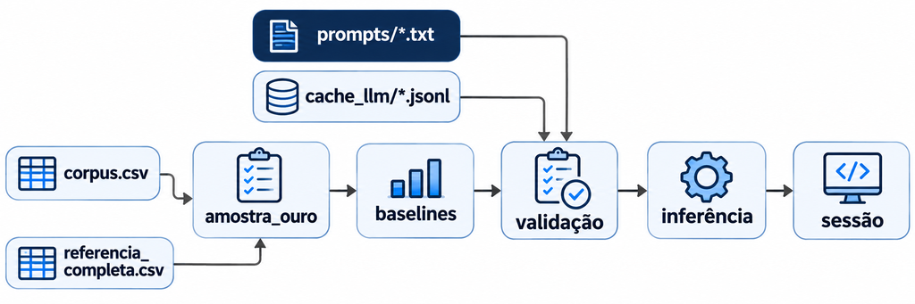

Editou um prompt? `validacao` e `inferencia` ficam desatualizadas; `amostra_ouro` e `baselines`, não.

## Uma armadilha do próprio `targets`

**Encontrada na verificação deste material**

Com `format = "file"` apenas, o `targets` detecta **edições** em arquivos conhecidos, mas **não detecta arquivos novos**: `list.files()` não é reexecutado, porque seu código não mudou. Um prompt v4 ou uma nova execução do LLM passariam **em silêncio**.

**Correção:** `cue = tar_cue(mode = "always")` nas entradas que listam pastas. A lista é refeita sempre; as etapas seguintes só rodam se o conteúdo mudou.

**Lição:** ferramentas de reprodutibilidade **também precisam ser testadas**.

## A identidade do instrumento, no cache

```r
llm |>
  distinct(modelo, modelo_digest, ollama_versao, prompt_id, prompt_sha, temperatura, semente) |>
  arrange(prompt_id, temperatura, semente)
```

```
#> # A tibble: 6 × 7
#>   modelo           modelo_digest ollama_versao prompt_id prompt_sha   temperatura semente
#>   <chr>            <chr>         <chr>         <chr>     <chr>              <dbl>   <int>
#> 1 s5-nano-instruct 85ec77c8f04e  0.40.15       v1        5eb0f92ea13d         0        42
#> 2 s5-nano-instruct 85ec77c8f04e  0.40.15       v2        c4b5a5ade801         0        42
#> 3 s5-nano-instruct 85ec77c8f04e  0.40.15       v2        c4b5a5ade801         0.8       1
#> 4 s5-nano-instruct 85ec77c8f04e  0.40.15       v2        c4b5a5ade801         0.8       2
#> 5 s5-nano-instruct 85ec77c8f04e  0.40.15       v2        c4b5a5ade801         0.8       3
#> 6 s5-nano-instruct 85ec77c8f04e  0.40.15       v3        6fdbfaf1d613         0        42
```

```r
range(llm$timestamp)
```

```
#> [1] "2026-11-12T02:36:44+00:00" "2026-11-12T02:48:22+00:00"
```

`s5-nano-instruct` é só um **apelido local**: o *digest* identifica os pesos. A versão do Ollama entra porque **o software que executa o modelo também é parte do instrumento**.

## *Drift*: quando o instrumento muda sozinho

- **API comercial** atualiza o modelo → mesmo prompt, **outra medida**
- Defesa: **modelo local com versão fixa**, ou registrar `model_id` + data + respostas brutas
- **Monitorar:** re-anotar periodicamente a amostra-ouro e acompanhar o kappa

E um modelo **local**, com os mesmos pesos, o mesmo prompt e temperatura 0… dá sempre a mesma resposta?

## Repetindo a medição

```r
le_jsonl <- \(a) jsonlite::stream_in(file(a), verbose = FALSE)
repet <- map(c("v1", "v2", "v3"), \(p) {
  arq <- paste0("s5-nano-instruct__", p, "__t0.0__s42.jsonl")
  a <- le_jsonl(file.path("dados/cache_llm", arq)); b <- le_jsonl(file.path("dados/repeticao", arq))
  inner_join(select(a, doc_id, antes = categoria_llm, dg_a = modelo_digest, ov_a = ollama_versao),
             select(b, doc_id, depois = categoria_llm, dg_b = modelo_digest, ov_b = ollama_versao),
             by = "doc_id") |> mutate(prompt = p)
}) |> list_rbind()
repet |>
  group_by(prompt) |>
  summarise(n = n(), mesmo_instrumento = all(dg_a == dg_b & ov_a == ov_b), mudaram = sum(antes != depois))
```

```
#> # A tibble: 3 × 4
#>   prompt     n mesmo_instrumento mudaram
#>   <chr>  <int> <lgl>               <int>
#> 1 v1       304 TRUE                    0
#> 2 v2       304 TRUE                    3
#> 3 v3       304 TRUE                    2
```

## Quais mudaram?

```r
repet |>
  filter(antes != depois) |>
  left_join(select(corpus, doc_id, ementa), by = "doc_id") |>
  transmute(prompt, doc_id, antes, depois, ementa = str_trunc(ementa, 80)) |>
  knitr::kable()
```

| prompt | doc_id | antes | depois | ementa |
| --- | --- | --- | --- | --- |
| v2 | doc0059 | REGULAR | PUNIR | Institui campanha de prevenção e combate aos crimes digitais contra crianças,… |
| v2 | doc0233 | PUNIR | REGULAR | Dispõe sobre medidas de prevenção, combate e responsabilização relacionadas à… |
| v2 | doc0255 | OUTRO | PROMOVER | Institui o Programa Nacional de Municípios Inteligentes e Sustentáveis, cria … |
| v3 | doc0267 | PROMOVER | REGULAR | Altera a Lei nº 12.651, de 25 de maio de 2012 (Código Florestal), para instit… |
| v3 | doc0272 | PUNIR | REGULAR | Altera a Lei nº 13.105, de 16 de março de 2015, para caracterizar como ato at… |

**Importante**

**Temperatura 0 não garante a mesma resposta**: pequenas diferenças numéricas na GPU trocam a resposta mais provável quando há quase empate. A replicação exata vem do **cache**, não de reexecutar o modelo.

## O ambiente

```r
cat(readLines("resultados/sessionInfo.txt")[1:3], sep = "\n")
```

[output not shown]

```r
c(R = R.version.string, targets = as.character(packageVersion("targets")),
  glmnet = as.character(packageVersion("glmnet")), httr2 = as.character(packageVersion("httr2")))
```

```
#>                              R                        targets                         glmnet
#> "R version 4.6.2 (2026-10-29)"                       "1.12.0"                          "5.1"
#>                          httr2
#>                        "1.3.0"
```

```r
cat(readLines("requirements.txt"), sep = "\n")
```

```
#> # Trilha Python do minicurso (testado com Python 3.11)
#> pandas>=2.0
#> numpy>=1.24
#> requests>=2.31
#> scikit-learn>=1.3
#> matplotlib>=3.7
#> jupyter
#> # opcional (API comercial):
#> # openai>=1.40
```

## R e Python: os mesmos números?

```r
comp <- inner_join(
  read_csv("resultados/tabelas/estimativas_punir.csv") |> select(estimador, R = estimativa, R_li = li),
  read_csv("resultados/python/tabelas/estimativas_punir.csv") |> select(estimador, Python = estimativa, Py_li = li),
  by = "estimador")
comp |> mutate(dif = Python - R, dif_li = Py_li - R_li) |> mutate(across(where(is.double), \(x) round(x, 4)))
```

```
#> # A tibble: 4 × 7
#>   estimador                     R  R_li Python Py_li   dif dif_li
#>   <chr>                     <dbl> <dbl>  <dbl> <dbl> <dbl>  <dbl>
#> 1 Só humanos (amostra-ouro) 0.183 0.114  0.183 0.114     0      0
#> 2 Ingênuo (LLM = verdade)   0.230 0.183  0.230 0.183     0      0
#> 3 PPI                       0.206 0.136  0.206 0.136     0      0
#> 4 PPI++                     0.194 0.144  0.194 0.144     0      0
```

Mesmas estimativas. Diferenças só no que depende do gerador aleatório (ICs bootstrap, simulação) e no TF-IDF (bloco 3). Até o hash do prompt é calculado igual nas duas linguagens.

## Código gerado por IA

Agentes de programação (Claude Code, Codex e similares) também produzem análises.

**Regra proposta**

**Trate o código gerado por IA como o de um coautor**: revisão, testes, versionamento. Quem publica responde por ele.

- Este material foi produzido com o auxílio do **Claude Opus 5.5** (Anthropic)
- A verificação de ponta a ponta encontrou e corrigiu falhas reais: o `tar_cue`, caches de outro modelo sendo lidos junto, o erro 504 sem *retry*
- Os dois papéis não se confundem: o **S5-nano** é o instrumento estudado; o **Claude** foi o auxiliar na produção

## Checklist para o seu próximo artigo

```r
chk <- readLines("CHECKLIST.md")
cat(str_trunc(grep("^## |^- \\[ \\]", chk, value = TRUE)[c(1:6, 13:17)], 110), sep = "\n")
```

```
#> ## A. Antes de anotar
#> - [ ] A **pergunta de pesquisa** e o **conceito** a medir estão definidos sem depender do LLM?
#> - [ ] Existe um **livro de códigos** escrito, com definições, regras de decisão e exemplos?
#> - [ ] O livro de códigos foi testado com **codificadores humanos** e a concordância entre eles foi medida (...
#> - [ ] A **amostra-ouro** é **aleatória** e de tamanho justificado (custo × precisão)?
#> - [ ] Há um **baseline barato** (dicionário, modelo clássico) para comparar?
#> - [ ] **Falhas de formato** contadas e tratadas de forma explícita (não descartadas em silêncio).
#> - [ ] Dados sensíveis? Preferir **modelo local**; checar termos de uso da API.
#> ## C. Validação
#> - [ ] **Validade**: acurácia, F1 macro e kappa contra a amostra-ouro, **com intervalo de confiança**.
#> - [ ] **Matriz de confusão** inspecionada: em quais categorias o modelo erra?
```

## Resumo do bloco 7

**Executamos**

- leitura do pipeline com `tar_manifest()`
- identidade do instrumento no cache
- repetição a t = 0 (*drift* local)
- comparação R × Python

**A lição**

- versionar **instrumento** e **respostas**, não só código
- o cache é o que permite replicar
- ferramentas de reprodutibilidade também falham: **teste-as**

# 8 · Ética, limites e debate

## IA na política brasileira em 2026

### Eleições (TSE)

- Res. 23.755/2026: **rotulagem** de conteúdo sintético
- **Deepfakes** proibidos, mesmo com autorização
- Vedação de novos conteúdos sintéticos **72h antes / 24h depois** da votação
- IA não pode **recomendar voto**

## O que o nosso corpus diz sobre eleições

```r
corpus |>
  left_join(select(ref, doc_id, categoria, eleitoral), by = "doc_id") |>
  count(ano_eleitoral = if_else(ano_eleitoral, "ano eleitoral", "ano não eleitoral"),
        eleitoral = if_else(eleitoral == 1, "tema eleitoral", "outro tema")) |>
  tidyr::pivot_wider(names_from = eleitoral, values_from = n)
```

```
#> # A tibble: 2 × 3
#>   ano_eleitoral     `outro tema` `tema eleitoral`
#>   <chr>                    <int>            <int>
#> 1 ano eleitoral              172                8
#> 2 ano não eleitoral          119                5
```

Referência preliminar. Para uma afirmação sobre o Congresso, o mesmo cuidado do bloco 6: rótulo do LLM + amostra-ouro + PPI, e não contagem ingênua.

## Para debater

1. Se um LLM classifica 304 ementas em poucos minutos, ainda precisamos de codificadores humanos? **Para quê, exatamente?**
2. Modelo **local** (reprodutível) com kappa menor × API **comercial** com kappa maior?
3. O **viés político** dos LLMs (Motoki et al., 2024) pode contaminar comparações entre campos? Como testar com o que fizemos hoje?
4. Rotulagem obrigatória de conteúdo sintético é **verificável**? Quem audita o detector, e com que amostra-ouro?

## Quando **não** usar um LLM

- O conceito não tem **definição operacional** clara (o LLM vai inventar uma)
- Não há como montar uma **amostra-ouro** (então não há como validar nem corrigir)
- O erro do modelo é **correlacionado** com a variável explicativa e não pode ser corrigido
- Poucos documentos: codificar à mão é mais barato e mais confiável
- Os dados não podem sair da instituição e não há modelo local adequado

## O que fizemos em código

| Bloco | Funções executadas | Saída principal |
| --- | --- | --- |
| 1 · Dados | `req_json`, `camara_partido_na_data`, `extrai_partido_senado`, `limpa_ementa` | `corpus.csv` |
| 2 · Codificação | `sample` com semente, `carrega_ouro` | amostra-ouro de 120 |
| 3 · Baselines | `classifica_dicionario`, `kappa_cohen`, `cv.glmnet` | régua sem LLM |
| 4 · LLM | `chama_ollama`, `extrai_rotulo`, `anota_corpus`, `carrega_llm` | cache com 6 execuções |
| 5 · Validação | `boot_ic`, `resumo_metricas`, `alfa_krippendorff`, `glm` | validade, viés, confiabilidade |
| 6 · Inferência | `est_humano`, `est_ingenuo`, `est_ppi`, `est_ppi_plus`, `simula` | proporção PUNIR com IC honesto |
| 7 · Reprodutibilidade | `tar_manifest`, comparação de caches | *drift* e replicação |

## Mensagem final

**Importante**

A IA amplia as formas de responder,  
mas **não substitui** a boa pergunta, o desenho de pesquisa e a **validação estatística**.

- **Material completo:** R + dados + cache do LLM

**Jodavid Ferreira** · jodavid.ferreira@ufpe.br · jodavid.github.io

## Referências

- Angelopoulos, A. N. et al. (2023). Prediction-powered inference. *Science*, 382(6671).
- Angelopoulos, A. N.; Duchi, J.; Zrnic, T. (2023). PPI++: Efficient prediction-powered inference. *arXiv:2311.01453*.
- Bolognesi, B.; Ribeiro, E.; Codato, A. (2023). A new ideological classification of Brazilian political parties. *Dados*, 66(2).
- Breiman, L. (2001). Statistical modeling: the two cultures. *Statistical Science*, 16(3).
- Chernozhukov, V. et al. (2018). Double/debiased machine learning. *The Econometrics Journal*, 21(1).
- Cohen, J. (1960). A coefficient of agreement for nominal scales. *Educational and Psychological Measurement*, 20(1).
- Egami, N. et al. (2023). Using imperfect surrogates for downstream inference. *NeurIPS*.
- Gilardi, F.; Alizadeh, M.; Kubli, M. (2023). ChatGPT outperforms crowd workers for text-annotation tasks. *PNAS*, 120(30).
- Grimmer, J.; Roberts, M.; Stewart, B. (2022). *Text as Data*. Princeton University Press.
- Krippendorff, K. (2018). *Content Analysis* (4ª ed.). SAGE.
- Landau, W. M. (2021). The targets R package. *JOSS*, 6(57).
- Landis, J. R.; Koch, G. G. (1977). The measurement of observer agreement for categorical data. *Biometrics*, 33(1).
- Motoki, F.; Pinho Neto, V.; Rodrigues, V. (2024). More human than human: measuring ChatGPT political bias. *Public Choice*, 198.
- Tribunal Superior Eleitoral. Resolução nº 23.755, de 2 de março de 2026.
- Vovk, V.; Gammerman, A.; Shafer, G. (2005). *Algorithmic Learning in a Random World*. Springer.